# Epidemiology of Co-Colonized Methicillin Resistant Staphylococcus aureus Associated ABSSSI

# Introduction

R language Rmarkdown document to accompany *Epidemiology of Co-Colonized Methicillin Resistant Staphylococcus aureus Associated Acute Bacterial Skin and Skin Structure Infection*.

Cleaning of study data began in SAS v9.2 and project migrated to R shortly thereafter. Several sections of this analysis code did not contribute to the manuscript, they are left in the document to demonstrate data exploration and possible methods of analysis.

# Libraries

```r
library(haven)       # import data - sas7bdat
library(tidyverse)   # suite of data cleaning, processing, management functions
library(magrittr)    # add() function, and `%<>%`
library(visdat)      # visualize whole data frames
library(tableone)    # CreateTableOne package
library(knitr)       # Rmarkdown tables
library(kableExtra)  # make Rmarkdown tables pretty
```

# Source Data

```r
setwd("S:/MartinEpi/Projects/Co-Infx/project/data")

files <- list.files(pattern = "*.sas7bdat")
file.names <- gsub(".sas7bdat", "", files)

for (i in 1:length(files)) {
  assign(file.names[i], read_sas(files[i]))
}
```

# Process Data

```r
# dput(colnames(main_fixed))
dates_to_convert <- c("adm_dat", "cult_dat")
numeric_to_factor <- c("male", "obese", "eth", "race", "resid", "ltcf", "wound",
                       "neutro", "surg_yr", "abx_yr", "device",
                       "diabetes", "diab_com", "amputat",
                       "retino", "neuro", "nephro", "hba_4", "renal", "chr_wnd", "wnd_site",
                       "wnd_pre", "steroid", "chemothp", "radiothp", "post_trn",
                       "ulcer", "ulc_stg1", "ulc_stg2", "ulc_stg3",
                       "ulc_stg4", "cssti", "sepsis", "new_icu", "new_int", "new_surg",
                       "new_proc", "new_cvc", "new_uc", "new_arf", "new_liv", "new_endo",
                       "vaso", "abx_indx", "res_sus", "gram", "aerobe", "poly_infx",
                       "res_org", "bacter", "iso_org", "gram_r", "aerobe_r", "post_stat",
                       "fail_dth", "read_30", "infx_doc", "trt_fail",
                       "fail_res1", "fail_res2",
                       "fail_icu", "fail_org", "fail_reop", "fail_infx",
                       "fail_tot", "eld", "ulc", "extremity", "dth_study", "cssti1",
                       "cssti2", "cssti3", "cssti4", "year", "hosp", "black", "white",
                       "other", "home", "ltacf", "oth_resid", "emia", "EMDTH", "kidney",
                       "charl_cat", "cssti_lev", "vre",
                       "switch", "switch_30", "dth_30"
                       )

tmp_fn <- function(x) as.Date(x, origin = "1960-01-01")

main <- main_fixed %>%
  mutate(
    hba_4 = ifelse(hba_4 == '.' | hba_4 == '', NA, hba_4),
    ulc_stg2 = ifelse(ulc_stg2 == '', NA, ulc_stg2),
    ulc_stg3 = ifelse(ulc_stg3 == '', NA, ulc_stg3),
    ulc_stg4 = ifelse(ulc_stg4 == '', NA, ulc_stg4),
    fail_res2 = ifelse(fail_res2 == '', NA, fail_res2),
    fail_dat = as.Date(fail_dat, "%m/%d/%Y")
  ) %>%
  mutate_at(dates_to_convert, funs(tmp_fn)) %>%
  mutate_at(numeric_to_factor, funs(factor))
```

# Explore

## Table 1

### Continuous variables age and BMI

```r
print(CreateTableOne(vars = c("age", "bmi"),
                     strata = "poly_infx",
                     data = main),
      nonnormal = c("age", "bmi"))
```

```
                    Stratified by poly_infx
                     0                    1                    p
  n                    435                  253
  age (median [IQR]) 49.00 [37.00, 61.00] 59.00 [46.00, 72.00] <0.001
  bmi (median [IQR]) 28.05 [24.10, 33.05] 26.50 [22.59, 31.60]  0.011
                    Stratified by poly_infx
                     test
  n
  age (median [IQR]) nonnorm
  bmi (median [IQR]) nonnorm
```

### Categorical variables

```r
# dput(colnames(main))
cont_vars <- c("male","obese", "eth", "race", "resid", "ltcf", "wound",
              "neutro", "surg_yr", "abx_yr", "device",
              "diabetes", "diab_com", "amputat",
              "retino", "neuro", "nephro", "hba_4", "renal", "chr_wnd",
              "wnd_site", "steroid", "chemothp", "radiothp", "post_trn",
              "ulcer", "ulc_stg1", "ulc_stg2", "ulc_stg3",
              "ulc_stg4", "cssti", "sepsis", "new_icu", "new_int", "new_surg",
              "new_proc", "new_cvc", "new_uc", "new_arf", "new_liv", "new_endo",
              "vaso", "abx_indx", "res_sus", "gram", "aerobe",
              "res_org",  "bacter", "iso_org", "gram_r", "aerobe_r",
              "post_stat", "fail_dth", "read_30",
              "infx_doc", "trt_fail", "fail_res1", "fail_res2",
              "fail_icu", "fail_org", "fail_reop", "fail_infx",
              "eld", "ulc", "extremity", "dth_study", "cssti1",
              "cssti2", "cssti3", "cssti4", "year", "hosp", "black", "white",
              "other", "home", "ltacf", "oth_resid", "emia", "EMDTH", "kidney",
              "charl_cat", "cssti_lev", "switch", "switch_30", "dth_30")

print(CreateTableOne(vars = cont_vars,
                     strata = "poly_infx",
                     data = main,
                     argsApprox = list(correct = FALSE)))
```

```
                   Stratified by poly_infx
                    0            1            p      test
  n                 435          253
  male = 1 (%)      245 ( 56.3)  144 ( 56.9)   0.879
  obese = 1 (%)     143 ( 41.2)   67 ( 33.2)   0.062
  eth = 1 (%)        22 (  5.4)   12 (  4.9)   0.781
  race (%)                                     0.770
     0                1 (  0.2)    0 (  0.0)
     2                1 (  0.2)    0 (  0.0)
     4              280 ( 67.5)  170 ( 68.5)
     5              107 ( 25.8)   66 ( 26.6)
     6               26 (  6.3)   12 (  4.8)
  resid (%)                                   <0.001
     1              334 ( 85.4)  128 ( 56.4)
     2               34 (  8.7)   87 ( 38.3)
     3               23 (  5.9)   12 (  5.3)
  ltcf (%)                                     0.446
     1               28 ( 77.8)   73 ( 83.0)
     2                1 (  2.8)    5 (  5.7)
     3                2 (  5.6)    5 (  5.7)
 [ reached getOption("max.print") -- omitted 129 rows ]
```

## Categorize ABSSSI site of infection

```r
# table(main$infx_site) %>%
#   as.data.frame() %>%
#   head()

# main %>%
#   select(infx_site, infx_site1) %>%
#   filter(infx_site1 == '')

upper_extrem <- "antecubital|arm|axilla|elbow|eblow|forearm|armpit|wrist"
lower_extrem <- "lower extremity|ankle|leg|knee|calf|heel|heal|malleolus|malleouls|patela|tibia|tiba|lower extremeties"
buttock <- "glute|buttock|butttock|coccyx|sacrum|sacral|scral|gloeal|tailbone"
hand <- "finger|hand|thumb"
foot <- "toe|foot|feet|hallux"
abdomen <- "abdomen|abdominal|abominal|peg|suprapubic|j tube"
upper_body <- "breast|chest|shoulder|shcoulder|soulder|sternal|deltoid"
back_sides <- "epidural|back|neck|psoas|cervical|lumbar|spine|spinal|hip|ischial|ischium|flank|side"
blood <- "blood|picc|line sepsis"
head <- "face|facial|chin|head|eye|brow|cheek|ear|parotid|temporal|nasal|nose|scalp|buccal|mandibula"
groin_genitals <- "groin|inguinal|thigh|pelvic|pelvis|vulva|vulvar|penile|penis|scrotal|scrotum|vagina|vaginal"
rectal <- "rectal|peri-rectal|rectal|perineum|perineal"
respiratory <- "sputum|respiratory|tracheal|tracheostomy|lungs|lung"

grepl_case <- function(pattern, x) {
  return(grepl(pattern, x, ignore.case = TRUE, perl = TRUE))
}

main <- main %>%
  mutate(
    infx_site = gsub("\\s+", " ", infx_site),
    site = ifelse(grepl_case(upper_extrem, infx_site), 'Upper Extremity', ''),
    site = ifelse(grepl_case(lower_extrem, infx_site), 'Lower Extremity', site),
    site = ifelse(grepl("LLE|LE|RLE", infx_site), "Lower Extremity", site),
    site = ifelse(grepl_case(buttock, infx_site), 'Buttock', site),
    site = ifelse(grepl_case(hand, infx_site), 'Hand', site),
    site = ifelse(grepl_case(foot, infx_site), 'Foot', site),
    site = ifelse(grepl_case(abdomen, infx_site), 'Abdomen', site),
    site = ifelse(grepl_case(upper_body, infx_site), 'Upper Body', site),
    site = ifelse(grepl_case(back_sides, infx_site), 'Back and Sides', site),
    site = ifelse(grepl_case(blood, infx_site), 'Blood', site),
    site = ifelse(grepl_case(head, infx_site), 'Head', site),
    site = ifelse(grepl_case(groin_genitals, infx_site), 'Groin and Genitals', site),
    site = ifelse(grepl_case(rectal, infx_site), 'Rectal', site),
    site = ifelse(grepl_case(respiratory, infx_site), 'Respiratory', site),
    infx_site1 = gsub("\\s+", " ", infx_site1),
    site1 = ifelse(grepl_case(upper_extrem, infx_site1), 'Upper Extremity', ''),
    site1 = ifelse(grepl_case(lower_extrem, infx_site1), 'Lower Extremity', site1),
    site1 = ifelse(grepl("LLE|LE|RLE", infx_site1), "Lower Extremity", site1),
    site1 = ifelse(grepl_case(buttock, infx_site1), 'Buttock', site1),
    site1 = ifelse(grepl_case(hand, infx_site1), 'Hand', site1),
    site1 = ifelse(grepl_case(foot, infx_site1), 'Foot', site1),
    site1 = ifelse(grepl_case(abdomen, infx_site1), 'Abdomen', site1),
    site1 = ifelse(grepl_case(upper_body, infx_site1), 'Upper Body', site1),
    site1 = ifelse(grepl_case(back_sides, infx_site1), 'Back and Sides', site1),
    site1 = ifelse(grepl_case(blood, infx_site1), 'Blood', site1),
    site1 = ifelse(grepl_case(head, infx_site1), 'Head', site1),
    site1 = ifelse(grepl_case(groin_genitals, infx_site1), 'Groin and Genitals', site1),
    site1 = ifelse(grepl_case(rectal, infx_site1), 'Rectal', site1),
    site1 = ifelse(grepl_case(respiratory, infx_site1), 'Respiratory', site1),
    site1 = ifelse(site1 == '', 'Unknown', site1),

    site1 = ifelse((site1 == '' & site == 'Buttock'), 'Buttock', site1),
    site1 = ifelse((site1 == '' & site == 'Blood'), 'Blood', site1),
    site1 = ifelse((site1 == '' & site == 'Foot'), 'Foot', site1)
    )
```

Good enough for now

```r
levs <- c("Head", "Upper Body", "Upper Extremity", "Hand", "Abdomen",
          "Back and Sides", "Buttock", "Rectal", "Groin and Genitals",
          "Lower Extremity", "Foot")

sites_orgs <- main %>%
  filter(poly_infx == 1) %>%
  select(id, site1, abau:citro, unidentified) %>%
  mutate(site1 = factor(site1, levels = levs))

totals <- data.frame(
  organism = names(sites_orgs[, -c(1, 2)]),
  sum = sapply(sites_orgs[, -c(1, 2)], sum)
  ) %>%
  mutate(perc = round((sum / sum(sum)) * 100, 1))

totals
```

```
       organism sum perc
1          abau  25  4.7
2     afaecalis   3  0.6
3         aturi   1  0.2
4        aureus   7  1.3
5    b_fragilis   1  0.2
6     bacteroid   4  0.7
7         clost   2  0.4
8       candida  12  2.2
9      albicans  21  3.9
10        cfreu   3  0.6
11       coryne  54 10.1
12        ecloa  12  2.2
13        ecoli  28  5.2
14      faecium  14  2.6
15     faecalis  37  6.9
16       entero  14  2.6
17        eaero   5  0.9
18    eikenella   1  0.2
19     fusarium   1  0.2
20        strep  23  4.3
21        sagal  22  4.1
22      spyogen   3  0.6
23     sviridan  16  3.0
24       sangin   2  0.4
25       hinflu   1  0.2
 [ reached getOption("max.print") -- omitted 20 rows ]
```

## Categorize into aerobic vs. non-aerobic, gram (-) vs. (+), and fungal and mixture

```r
anaerobes <- c("b_fragilis", "bacteroid", "clost", "pepto")
gram_neg <- c("aeru", "ecoli", "abau", "mirab", "kpneu", "eaero", "ecloa",
              "proteus", "providencia", "morgan", "cfreu", "koxy", "afaecalis",
              "prevotella", "serratia", "malt", "vulgar", "eikenella", "hinflu",
              "mcatarr")
gram_pos <- c("coryne", "faecalis", "strep", "sagal", "staph", "sviridan",
              "faecium", "entero", "aureus", "lactobac", "spyogen", "sangin",
              "aturi", "micro", "mavium")
fungal <- c("albicans", "candida", "yeast", "fusarium")

indicate_orgs <- function(df, str) {
  ifelse(rowSums(df[, str]) >= 1, 1, 0)
}

main$anaerobic <- indicate_orgs(main, anaerobes)
main$gram_neg <- indicate_orgs(main, gram_neg)
main$gram_pos <- indicate_orgs(main, gram_pos)
main$fungal <- indicate_orgs(main, fungal)

types <- c("anaerobic", "gram_neg", "gram_pos", "fungal")
main <- main %>%
  mutate(
    infx_type = ifelse(anaerobic == 1, 'Anaerobic', ''),
    infx_type = ifelse(gram_neg == 1,  'Gram Negative', infx_type),
    infx_type = ifelse(gram_pos == 1,  'Gram Positive', infx_type),
    infx_type = ifelse(fungal == 1, 'Fungal', infx_type),
    infx_type = ifelse(anaerobic == 1 & gram_neg == 1,
                       'Anaerobic, Gram Negative',
                       infx_type),
    infx_type = ifelse(anaerobic == 1 & gram_pos == 1,
                       'Anaerobic, Gram Positive',
                       infx_type),
    infx_type = ifelse(anaerobic == 1 & fungal == 1,
                       'Anaerobic, Fungal',
                       infx_type),
    infx_type = ifelse(gram_neg == 1 & gram_pos == 1,
                       'Gram Negative, Gram Positive',
                       infx_type),
    infx_type = ifelse(gram_neg == 1 & fungal == 1,
                       'Gram Negative, Fungal',
                       infx_type),
    infx_type = ifelse(gram_pos == 1 & fungal == 1,
                       'Gram Positive, Fungal',
                       infx_type),
    infx_type = ifelse(anaerobic == 1 & gram_neg == 1 & gram_pos == 1 & fungal == 1,
                       'Anaerobic, Gram Negative, Gram Positive, Fungal',
                       infx_type)
  )
```

```r
sapply(main[, types], table)
```

```
  anaerobic gram_neg gram_pos fungal
0       677      548      521    650
1        11      140      167     38
```

```r
tab <- main %>%
  filter(poly_infx == 1 & infx_type != '') %>%
  select(infx_type, site1) %>%
  group_by(site1, infx_type) %>%
  summarise(count = n()) %>%
  ungroup() %>%
  mutate(percent = count / sum(count) * 100)

tab
```

```
# A tibble: 59 x 4
            site1                    infx_type count   percent
            <chr>                        <chr> <int>     <dbl>
 1        Abdomen     Anaerobic, Gram Negative     2 0.8097166
 2        Abdomen     Anaerobic, Gram Positive     1 0.4048583
 3        Abdomen                Gram Negative     3 1.2145749
 4        Abdomen        Gram Negative, Fungal     1 0.4048583
 5        Abdomen Gram Negative, Gram Positive     2 0.8097166
 6        Abdomen                Gram Positive    13 5.2631579
 7        Abdomen        Gram Positive, Fungal     2 0.8097166
 8 Back and Sides                    Anaerobic     1 0.4048583
 9 Back and Sides                Gram Negative     4 1.6194332
10 Back and Sides Gram Negative, Gram Positive     6 2.4291498
# ... with 49 more rows
```

How many organisms in each polymicrobial infection? Evidently, and intuitively, frequency of organisms in a wound increases bioburden. Can test this with outcomes against total count of organisms in polymicrobial MRSA ABSSSI.

```r
main <- main %>%
  mutate(
    org_sum = rowSums(.[c(116:159, 161)]),
    org_sum = ifelse(poly_infx == 0, NA, org_sum)
  )

psych::describe(main$org_sum)
```

```
   vars   n mean   sd median trimmed  mad min max range skew kurtosis   se
X1    1 253 2.12 1.47      2    1.85 1.48   1  11    10 2.16     6.78 0.09
```

Fix VRE

```r
main <- main %>%
  mutate(
    vre = ifelse(grepl("VRE", resist), 1, 0),
    tmp = as.character(resist),
    tmp = tolower(tmp),
    tmp = gsub(" ", "", tmp),
    vre_faecalis = ifelse(grepl("vre.faecalis", tmp), 1, 0),
    vre_faecium = ifelse(grepl("vre.faecium", tmp), 1, 0)
  ) %>%
  select(-tmp)
```

```r
with(main, table(vre_faecalis, faecalis))
```

```
            faecalis
vre_faecalis   0   1
           0 651  21
           1   0  16
```

```r
with(main, table(vre_faecium, faecium))
```

```
           faecium
vre_faecium   0   1
          0 674   4
          1   0  10
```

## By ABSSSI Site

### Overall abundance per site

```r
data.frame(table(main$site1))
```

```
                 Var1 Freq
1             Abdomen   59
2      Back and Sides   63
3               Blood    6
4             Buttock   90
5                Foot   82
6  Groin and Genitals   62
7                Hand   23
8                Head   45
9     Lower Extremity  139
10             Rectal   10
11        Respiratory    3
12            Unknown   10
13         Upper Body   32
14    Upper Extremity   64
```

By co-colonizing site

```r
sites <- main[main$poly_infx == 1, "site1"]
data.frame(table(sites))
```

```
                sites Freq
1             Abdomen   24
2      Back and Sides   20
3               Blood    4
4             Buttock   47
5                Foot   46
6  Groin and Genitals   13
7                Hand    5
8                Head    7
9     Lower Extremity   54
10             Rectal    3
11        Respiratory    2
12            Unknown    5
13         Upper Body    8
14    Upper Extremity   15
```

### Most abundant Co-colonizing organisms by ABSSSI site

```r
co_colony.df <- main %>%
  filter(poly_infx == 1) %>%
  select(id, site1, abau:citro, unidentified, infx_type, cssti, diabetes)

co_colony.df %>%
  select(-id, -infx_type, -unidentified, -coryne, -cssti, -diabetes) %>%
  reshape2::melt(id.vars = "site1") %>%
  plyr::ddply(plyr::.(site1, variable),
              summarise,
              sum = sum(value)) %>%
  group_by(site1) %>%
  mutate(max = max(sum)) %>%
  filter(sum == max)
```

```
# A tibble: 23 x 4
# Groups: site1 [14]
   site1          variable   sum   max
   <chr>          <fctr>   <dbl> <dbl>
 1 Abdomen        strep     4.00  4.00
 2 Abdomen        aeru      4.00  4.00
 3 Back and Sides abau      3.00  3.00
 4 Back and Sides aeru      3.00  3.00
 5 Blood          aureus    1.00  1.00
 6 Blood          faecium   1.00  1.00
 7 Blood          faecalis  1.00  1.00
 8 Blood          staph     1.00  1.00
 9 Buttock        aeru     11.0  11.0
10 Foot           faecalis 11.0  11.0
# ... with 13 more rows
```

## Heatmaps

Define heatMap function

```r
# import table
setwd("S:/MartinEpi/Projects/Co-Infx/project/documents/")
orgs <- readxl::read_excel("organism categories.xlsx", sheet = "type")
# head(orgs)

site_levels <- c("Head", "Upper Body", "Upper Extremity", "Hand",
                 "Abdomen", "Back and Sides",
                 "Buttock", "Rectal", "Groin and Genitals",
                 "Lower Extremity", "Foot")

# function to generate heatmaps for our specific needs
# requires ggplot2, magrittr
#' @param df data.frame object holding variables x, y, and fill
#' @param x vector of character or factor values for the x axis
#' @param y vector of character or factor values for the y axis
#' @param fill vector of numeric values for heat intensities
#' @param xlab label for x-axis
#' @param barheight height of the guide legend bar
#' @param barwidth width of the guide legend bar
#' @param legend_top position guide legend at top of heatmap
#' @param angle angle of x-axis ticks
#' @param yremove if TRUE, remove all y axis items

heatMap <- function(df, x, y, fill, xlab,
                    barheight = NULL, barwidth = NULL,
                    legend_top = FALSE,
                    angle = TRUE,
                    yremove = FALSE) {
  heat <- df %>%
    ggplot(aes_string(x = x, y = y, fill = fill)) %>%
    add(geom_tile()) %>%
    add(scale_fill_gradient(low = "navyblue",
                            high = "darkorange1")) %>%
    add(theme_minimal(14)) %>%
    add(scale_y_discrete(limits = rev(levels(df$variable)))) %>%
    add(labs(
      x = xlab,
      y = "",
      fill = "Proportion"
    ))
  if (angle)
    heat <- heat + theme(
      axis.text.x = element_text(angle = 45,
                                 hjust = 1,
                                 face = "bold")
    )
  if (legend_top)
    heat <- heat +
      theme(legend.position = "top") +
      guides(fill = guide_colorbar(barwidth = barwidth,
                                   barheight = barheight))
  else
    heat <- heat + guides(fill = guide_colorbar(barheight = barheight))
  if (yremove)
    heat <- heat + theme(
      axis.title.y = element_blank(),
      axis.text.y = element_blank(),
      axis.ticks.y = element_blank()
    )
  return(heat)
}
```

### All organisms by MRSA ABSSSI site

Need to combine some sites due to sparsity

```r
co_colony.comb <- co_colony.df %>%
  mutate(
    site1 = ifelse(site1 == 'Head', 'Upper Body', site1),
    site1 = ifelse(site1 == 'Hand', 'Upper Extremity', site1),
    site1 = ifelse(site1 == 'Rectal', 'Buttock', site1),
    site1 = ifelse(site1 == 'Foot', 'Lower Extremity', site1)
  )
```

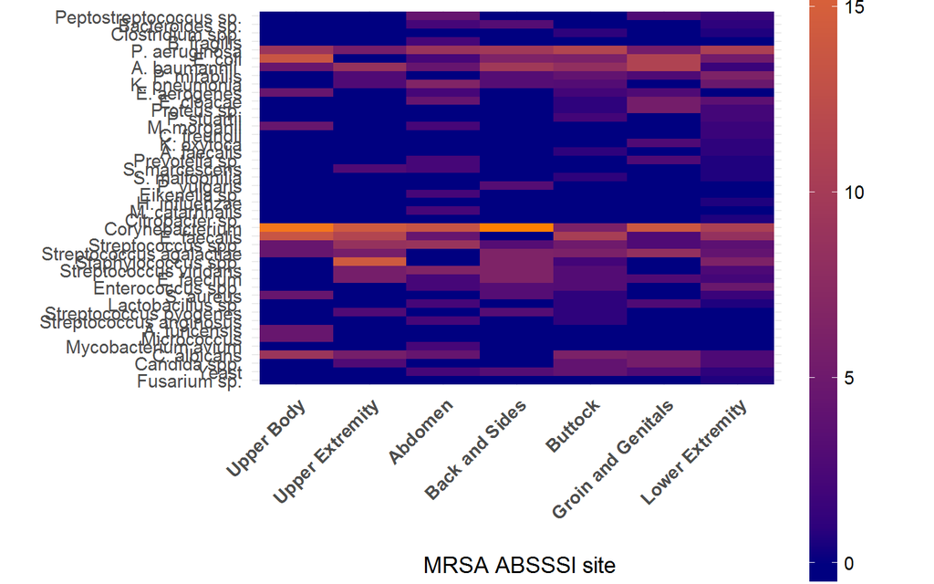

```r
site.heat1 <- co_colony.comb %>%
  filter(!(site1 %in% c('Respiratory', 'Unknown', 'Blood'))) %>%
  select(-id, -infx_type, -unidentified, -cssti, -diabetes) %>%
  reshape2::melt(id.vars = "site1") %>%
  mutate(
    site1 = factor(site1,
                   levels = site_levels,
                   labels = site_levels)
  ) %>%
  plyr::ddply(plyr::.(site1, variable),
              summarise,
              sum = sum(value)) %>%
  group_by(site1) %>%
  mutate(
    prop = (sum / sum(sum)) * 100,
    variable = as.character(variable),
    variable = factor(variable,
                      levels = orgs$varname,
                      labels = orgs$species)
    ) %>%
  ungroup()

site.heatmap1 <- heatMap(site.heat1, barheight = 31.75,
                         x = 'site1', y = 'variable', fill = 'prop',
                         xlab = "\n MRSA ABSSSI site")
site.heatmap1
```

```r
# setwd("S:/MartinEpi/Projects/Co-Infx/project/documents/")
# tiff("site_heatmap1_all_comb.tiff",
#      width = 6, height = 8, units = "in", res = 300)
# site.heatmap1
# dev.off()
```

### MRSA ABSSSI site by organism importance

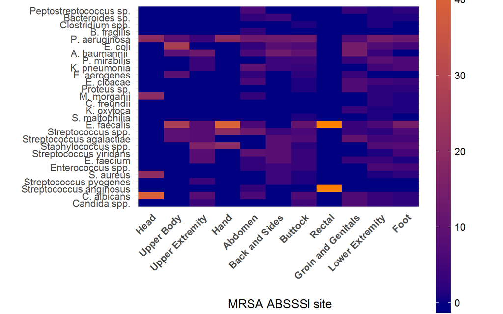

```r
important <- orgs %>%
  filter(!(varname %in% c('providencia', 'afaecalis', 'prevotella', 'serratia',
                          'eikenella', 'mcatarr', 'citro', 'coryne', 'lactobac',
                          'aturi', 'micro',' mavium', 'fusarium', 'yeast',
                          'hinflu', 'mavium', 'vulgar')))

site.heat2 <- co_colony.df %>%
  filter(!(site1 %in% c('Respiratory', 'Unknown', 'Blood'))) %>%
  select(-id, -infx_type, -unidentified, -cssti, -diabetes) %>%
  reshape2::melt(id.vars = "site1") %>%
  mutate(
    site1 = factor(site1,
                   levels = site_levels,
                   labels = site_levels)
  ) %>%
  filter(variable %in% important$varname) %>%
  plyr::ddply(plyr::.(site1, variable),
              summarise,
              sum = sum(value)) %>%
  group_by(site1) %>%
  mutate(
    prop = (sum / sum(sum)) * 100,
    variable = as.character(variable),
    variable = factor(variable,
                      levels = important$varname,
                      labels = important$species)
    ) %>% ungroup()

site.heatmap2 <- heatMap(site.heat2, barheight = 31.75,
                         x = "site1", y = "variable", fill = "prop",
                         xlab = "\n MRSA ABSSSI site")
site.heatmap2
```

```r
# setwd("S:/MartinEpi/Projects/Co-Infx/project/documents/")
# tiff("site_heatmap2_important_comb.tiff",
#      width = 6, height = 8, units = "in", res = 300)
# site.heatmap2
# dev.off()
```

### All organisms by ABSSSI/cSSTI class

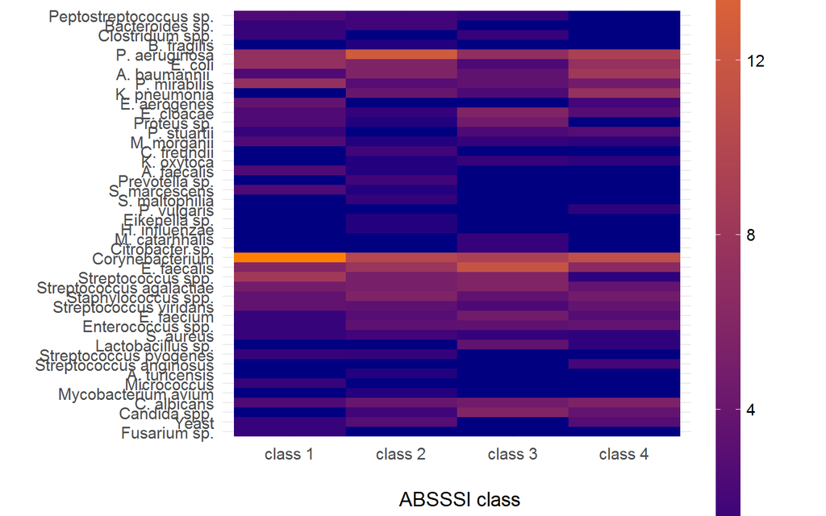

```r
cssti.heat1 <- co_colony.df %>%
  mutate(cssti = factor(cssti,
                        levels = paste0(seq(1:4)),
                        labels = paste0(rep("class ", 4), 1:4))) %>%
  filter(!(site1 %in% c('Respiratory', 'Unknown', 'Blood'))) %>%
  select(-id, -infx_type, -unidentified, -site1, -diabetes) %>%
  reshape2::melt(id.vars = "cssti") %>%
  plyr::ddply(plyr::.(cssti, variable),
              summarise,
              sum = sum(value)) %>%
  group_by(cssti) %>%
  mutate(
    prop = (sum / sum(sum)) * 100,
    variable = as.character(variable),
    variable = factor(variable,
                      levels = orgs$varname,
                      labels = orgs$species)
    ) %>% ungroup()

cssti.heatmap1 <- heatMap(cssti.heat1, barheight = 35.6,
                          x = "cssti", y = "variable", fill = "prop",
                          xlab = "\n ABSSSI class",
                          angle = FALSE)

cssti.heatmap1
```

```r
# setwd("S:/MartinEpi/Projects/Co-Infx/project/documents/")
# tiff("cssti_heatmap1_all_comb.tiff",
#      width = 6, height = 8, units = "in", res = 300)
# cssti.heatmap1
# dev.off()
```

### Important organisms by ABSSSI/cSSTI class

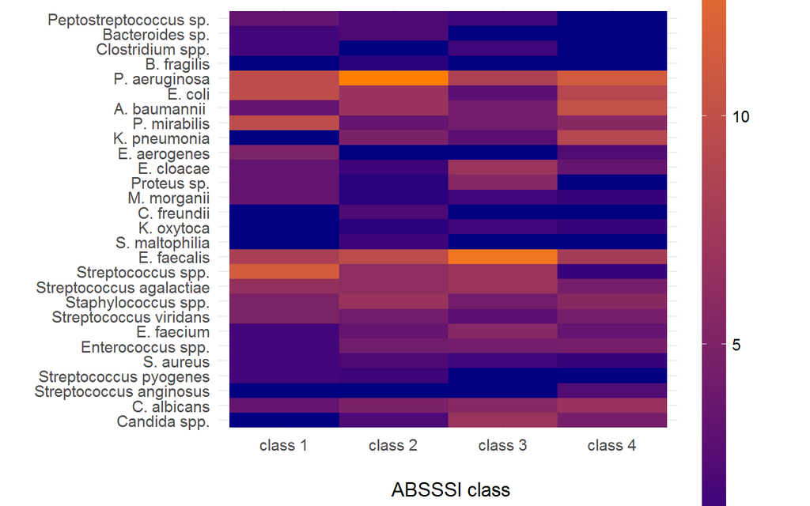

```r
cssti.heat2 <- co_colony.df %>%
  mutate(cssti = factor(cssti,
                        levels = paste0(seq(1:4)),
                        labels = paste0(rep("class ", 4), 1:4))) %>%
  filter(!(site1 %in% c('Respiratory', 'Unknown', 'Blood'))) %>%
  select(-id, -infx_type, -unidentified, -site1, -diabetes) %>%
  reshape2::melt(id.vars = "cssti") %>%
  filter(variable %in% important$varname) %>%
  plyr::ddply(plyr::.(cssti, variable),
              summarise,
              sum = sum(value)) %>%
  group_by(cssti) %>%
  mutate(
    prop = (sum / sum(sum)) * 100,
    variable = as.character(variable),
    variable = factor(variable,
                      levels = important$varname,
                      labels = important$species)
    ) %>% ungroup()

cssti.heatmap2 <- heatMap(cssti.heat2, barheight = 35.6,
                          x = "cssti", y = "variable", fill = "prop",
                          xlab = "\n ABSSSI class",
                          angle = FALSE)

cssti.heatmap2
```

```r
# setwd("S:/MartinEpi/Projects/Co-Infx/project/documents/")
# tiff("cssti_heatmap2_important.tiff",
#      width = 6, height = 8, units = "in", res = 300)
# cssti.heatmap2
# dev.off()
```

# Polymicrobial distribution analyses

multi-response permutation procedure (MRPP)

## Distribution differences by cSSTI/ABSSSI classification

Removing ‘rare’ species

```r
csstiXorg <- co_colony.df %>%
  select(cssti, aeru, ecoli, abau, mirab, kpneu, ecloa, proteus, coryne, strep,
         sagal, staph, faecium, faecalis, albicans, candida) %>%
  mutate(
    sumVar = rowSums(.[2:15]),
    cssti = factor(cssti,
                   levels = paste0(1:4),
                   labels = paste0(rep("Class ", 4), 1:4))) %>%
  filter(sumVar > 0) %>%
  select(-sumVar) %>%
  na.omit() %>%
  as.data.frame()
```

Performing the MRPP

```r
library(vegan)
set.seed(1233)
cssti.mrpp <- mrpp(csstiXorg[-1], csstiXorg$cssti, permutations = 1000)
cssti.mrpp
```

```
Call:
mrpp(dat = csstiXorg[-1], grouping = csstiXorg$cssti, permutations = 1000)

Dissimilarity index: euclidean
Weights for groups:  n

Class means and counts:

      Class 1 Class 2 Class 3 Class 4
delta 1.582   1.589   1.803   1.662
n     40      84      34      53

Chance corrected within-group agreement A: 0.003769
Based on observed delta 1.641 and expected delta 1.647

Significance of delta: 0.066933
Permutation: free
Number of permutations: 1000
```

Mean distance/mean within and between block dissimilarities. This calculates a matrix of mean within-cluster dissimilarities (the diagonal) and between-cluster dissimilarities (off-diagonal entries), and an attribute n of grouping counts.

```r
cssti.md <- meandist(vegdist(csstiXorg[-1]), csstiXorg$cssti)
summary(cssti.md)
```

```
Mean distances:
                 Average
within groups  0.8672998
between groups 0.8741970
overall        0.8722653

Summary statistics:
                          Statistic
MRPP A weights n        0.005503802
MRPP A weights n-1      0.005505537
MRPP A weights n(n-1)   0.005692655
Classification strength 0.006732497
```

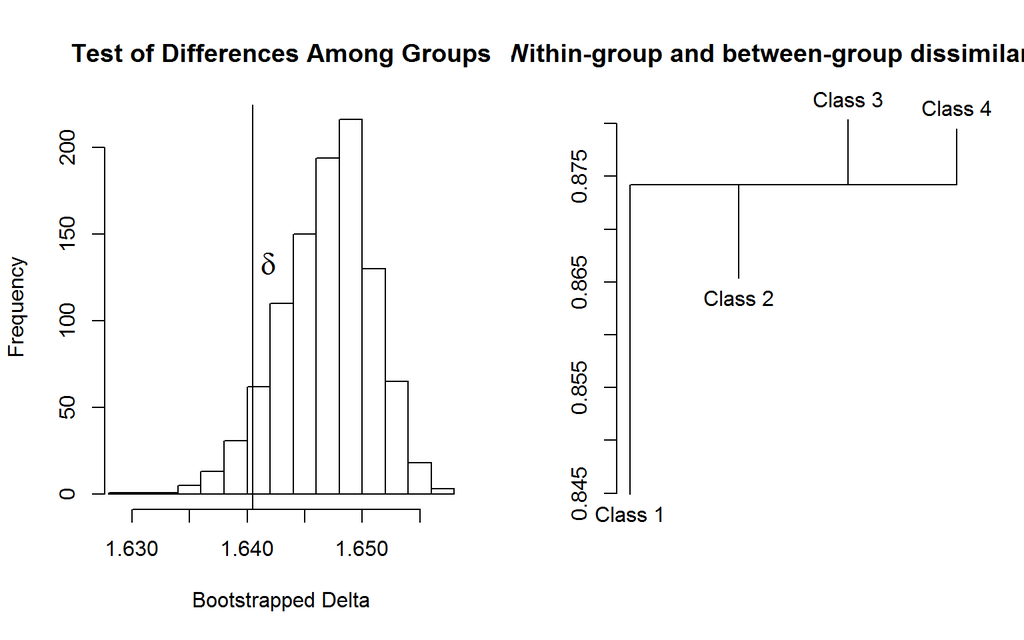

```r
par(mfrow = c(1, 2))
with(cssti.mrpp, {
  fig.dist <- hist(boot.deltas, xlim = range(c(delta, boot.deltas)),
                   main = "Test of Differences Among Groups",
                   xlab = "Bootstrapped Delta")
  abline(v = delta);
  text(delta, 2*mean(fig.dist$counts), adj = -0.5,
       expression(bold(delta)), cex = 1.5)
})
plot(cssti.md, kind = "histogram",
     main = "Within-group and between-group dissimilarities")
```

In the right-hand plot above, the horizontal line is drawn at the level of mean between-cluster dissimilarity and vertical lines connect within-cluster dissimilarities to this line.

## Distribution differences by diabetic status

Same treatment for diabetic patients (vs. non-diabetics)

```r
diabXorg <- co_colony.df %>%
  select(diabetes, aeru, ecoli, abau, mirab,
         kpneu, ecloa, coryne, strep, sagal,
         staph, faecium, faecalis, albicans,
         candida) %>%
  mutate(
    sumVar = rowSums(.[2:15]),
    diabetes = factor(diabetes,
                      levels = c(0, 1),
                      labels = c("Non-Diabetic", "Diabetic"))
    ) %>%
  filter(sumVar > 0) %>%
  select(-sumVar) %>%
  na.omit() %>%
  as.data.frame()
```

```r
set.seed(1233)
diab.mrpp <- mrpp(diabXorg[-1], diabXorg$diabetes, permutations = 1000)
diab.mrpp
```

```
Call:
mrpp(dat = diabXorg[-1], grouping = diabXorg$diabetes, permutations = 1000)

Dissimilarity index: euclidean
Weights for groups:  n

Class means and counts:

      Non-Diabetic Diabetic
delta 1.622        1.614
n     110          104

Chance corrected within-group agreement A: 0.005243
Based on observed delta 1.618 and expected delta 1.627

Significance of delta: 0.002997
Permutation: free
Number of permutations: 1000
```

Mean distance by diabetic grouping

```r
diab.md <- meandist(vegdist(diabXorg[-1]), diabXorg$diabetes)
summary(diab.md)
```

```
Mean distances:
                 Average
within groups  0.8666949
between groups 0.8805288
overall        0.8736389

Summary statistics:
                          Statistic
MRPP A weights n        0.007843158
MRPP A weights n-1      0.007844142
MRPP A weights n(n-1)   0.007948321
Classification strength 0.013742027
```

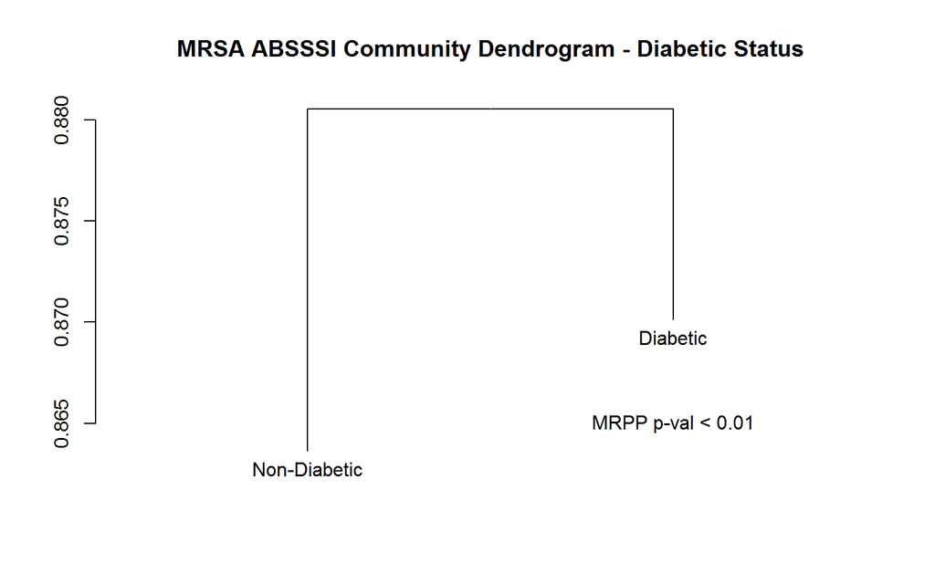

```r
plot(diab.md, kind = "dendrogram",
     main = "MRSA ABSSSI Community Dendrogram - Diabetic Status")
text(2, 0.865, "MRPP p-val < 0.01")
```

A ggplot2 version of this dendrogram

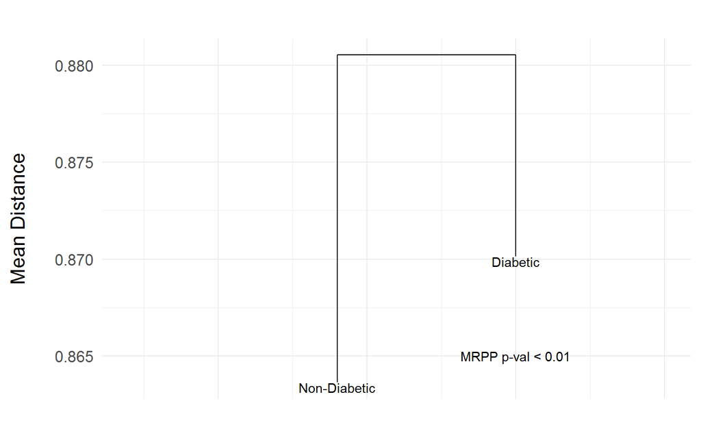

```r
dendro <- data.frame(
  x = c(0.4, 1),
  y = c(0.8636266, 0.8701293),
  label = c("Non-Diabetic", "Diabetic")
  ) %>%
  ggplot(aes(x = x, y = y, label = label)) %>%
  add(geom_segment(aes(x = 0.4, xend = 1, y = 0.8805288, yend = 0.8805288))) %>%
  add(geom_segment(aes(x = 0.4, xend = 0.4, y = 0.8805288, yend = 0.8636266))) %>%
  add(geom_segment(aes(x = 1, xend = 1, y = 0.8805288, yend = 0.8701293))) %>%
  add(geom_text(vjust = 1)) %>%
  add(annotate("text", x = 1, y = 0.865, label = "MRPP p-val < 0.01")) %>%
  add(expand_limits(x = c(-0.3, 1.5))) %>%
  add(theme_minimal(16)) %>%
  add(labs(
    x = "",
    y = "Mean Distance\n",
    title = ""
    )) %>%
  add(theme(
    axis.text.x = element_blank(),
    axis.line.x = element_blank(),
    plot.title = element_text(hjust = 0.5)
  ))
dendro
```

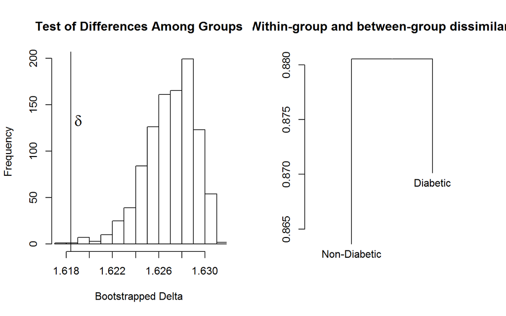

```r
par(mfrow = c(1, 2))
with(diab.mrpp, {
  fig.dist <- hist(boot.deltas, xlim = range(c(delta, boot.deltas)),
                   main = "Test of Differences Among Groups",
                   xlab = "Bootstrapped Delta")
  abline(v = delta);
  text(delta, 2 * mean(fig.dist$counts), adj = -0.5,
       expression(bold(delta)), cex = 1.5)
})
plot(diab.md, kind = "dendrogram",
     main = "Within-group and between-group dissimilarities")
```

Diabetics may have different distributions of organisms in their MRSA ABSSSIs (p = 0.002997).

Let’s look at a heatmap of co-colonizing organisms faceted by diabetic status to see if we can identify differences

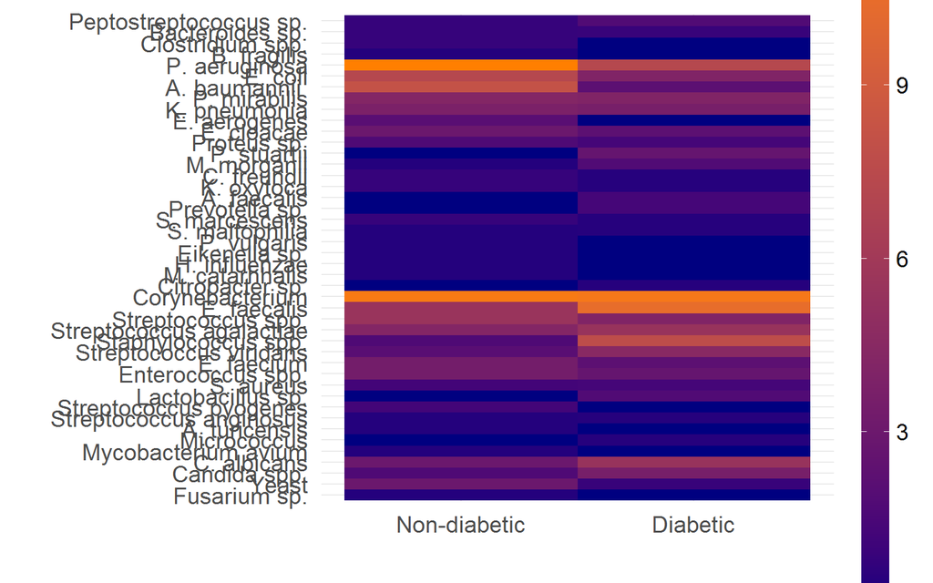

```r
diab.heat1 <- co_colony.df %>%
  mutate(diabetes = factor(diabetes,
                      levels = c(0, 1),
                      labels = c("Non-diabetic", "Diabetic"))) %>%
  filter(!(site1 %in% c('Respiratory', 'Unknown', 'Blood'))) %>%
  select(-id, -infx_type, -unidentified, -cssti, -site1) %>%
  reshape2::melt(id.vars = "diabetes") %>%
  plyr::ddply(plyr::.(diabetes, variable),
              summarise,
              sum = sum(value)) %>%
  group_by(diabetes) %>%
  mutate(
    prop = (sum / sum(sum)) * 100,
    variable = as.character(variable),
    variable = factor(variable,
                      levels = orgs$varname,
                      labels = orgs$species)
    ) %>%
  ungroup() %>%
  ggplot(aes(x = diabetes, y = variable)) %>%
  add(geom_tile(aes(fill = prop))) %>%
  add(scale_fill_gradient(low = "navyblue",
                          high = "darkorange1")) %>%
  add(theme_minimal(18)) %>%
  add(scale_y_discrete(limits = rev(levels(site.heat1$variable)))) %>%
  add(guides(fill = guide_colorbar(barheight = 30))) %>%
  add(labs(
    x = "",
    y = "",
    fill = "%"
    ))

diab.heat1
```

```r
# ggsave("diabetes_hmap_all.tiff", diab.heat1,
#        device = "tiff",
#        width = 8, height = 8, units = "in",
#        dpi = 700, compression = "lzw")
```

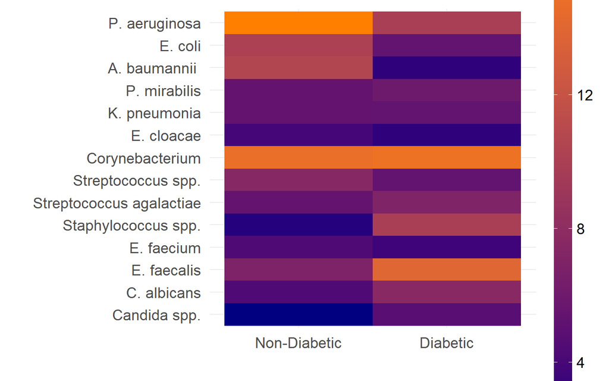

```r
factors <- orgs$species[c(5:9, 11, 26, 28:30, 32, 27, 41, 42)]

diab.heat2 <- diabXorg %>%
  reshape2::melt(id.vars = "diabetes") %>%
  plyr::ddply(plyr::.(diabetes, variable),
              summarise,
              sum = sum(value)) %>%
  group_by(diabetes) %>%
  mutate(
    prop = (sum / sum(sum)) * 100,
    variable = factor(variable,
                      labels = factors)
    ) %>%
  ungroup() %>%
  ggplot(aes(x = diabetes, y = variable)) %>%
  add(geom_tile(aes(fill = prop))) %>%
  add(scale_fill_gradient(low = "navyblue",
                          high = "darkorange1")) %>%
  add(theme_minimal(18)) %>%
  add(scale_y_discrete(limits = rev(factors))) %>%
  add(guides(fill = guide_colorbar(barheight = 30))) %>%
  add(labs(
    x = "",
    y = "",
    fill = "%"
    ))

diab.heat2
```

### Indicator species analysis

indicator species analysis using the methods of Legendre & Dufrene. The goal of indicator analysis is to determine which species can be used as indicators of certain site groups. The method calculates an index that measures the association between a species and a site group. Specifically, the index is calculated between the species for diabetics and non-diabetics and looks for the group corresponding to the highest association value, the statistical significance of this relationship is tested using a permutation test.

```r
library(indicspecies)
indic <- multipatt(diabXorg[-1], diabXorg$diabetes, control = how(nperm = 999))
summary(indic)
```

```
 Multilevel pattern analysis
 ---------------------------

 Association function: IndVal.g
 Significance level (alpha): 0.05

 Total number of species: 14
 Selected number of species: 2
 Number of species associated to 1 group: 2

 List of species associated to each combination:

 Group Non-Diabetic  #sps.  1
      stat p.value
abau 0.379   0.003 **

 Group Diabetic  #sps.  1
       stat p.value
staph 0.358   0.007 **
---
Signif. codes:  0 '***' 0.001 '**' 0.01 '*' 0.05 '.' 0.1 ' ' 1
```

*A. baumanii* is strongly and significantly associated with non-diabetic polymicrobial MRSA ABSSSI while *Staphylococcus spp.* are significantly associated with diabetic polymicrobial MRSA ABSSSI.

indicator value components

```r
summary(indic, indvalcomp = TRUE)
```

```
 Multilevel pattern analysis
 ---------------------------

 Association function: IndVal.g
 Significance level (alpha): 0.05

 Total number of species: 14
 Selected number of species: 2
 Number of species associated to 1 group: 2

 List of species associated to each combination:

 Group Non-Diabetic  #sps.  1
          A      B  stat p.value
abau 0.7909 0.1818 0.379   0.003 **

 Group Diabetic  #sps.  1
           A      B  stat p.value
staph 0.7824 0.1635 0.358   0.007 **
---
Signif. codes:  0 '***' 0.001 '**' 0.01 '*' 0.05 '.' 0.1 ' ' 1
```

The indicator value index is the product of two components, A and B:

- A: p(surveyed site belongs to target site | species has been found)
  - equivalent to *specificity* or *positive predictive value*
- B: p(finding the species in sites belonging to the side group)
  - equivalent to *sensitivity* or *fidelity*

Pearson’s $\phi$ coefficient of association for binary vectors can be used similar to the above:

```r
indic_cor <- multipatt(diabXorg[-1],
                       diabXorg$diabetes,
                       func = "r.g",
                       control = how(nperm = 999))
summary(indic_cor)
```

```
 Multilevel pattern analysis
 ---------------------------

 Association function: r.g
 Significance level (alpha): 0.05

 Total number of species: 14
 Selected number of species: 3
 Number of species associated to 1 group: 3

 List of species associated to each combination:

 Group Non-Diabetic  #sps.  2
      stat p.value
abau 0.210   0.005 **
aeru 0.142   0.044 *

 Group Diabetic  #sps.  1
       stat p.value
staph 0.193    0.01 **
---
Signif. codes:  0 '***' 0.001 '**' 0.01 '*' 0.05 '.' 0.1 ' ' 1
```

The differences between indicator analyses and correlation analyses are important: **correlation indices** are helpful for determining the preferences of species among groups (diabetics and non-diabetics) while **indicator value indices** are used for assessing the predictive values of species as indicators of those groups (diabetics vs. non-diabetics).

# Risk factor predictive modelling

```r
main_ml <- main %>%
  select(male, poly_infx, eld, obese, black, ltacf, diabetes,
         kidney, device, charl_cat, chr_wnd, surg_yr, abx_yr,
         cssti_lev, cult_days, steroid, ulc)
```

Impute missing data

```r
pMiss <- function(x) (sum(is.na(x)) / length(x)) * 100
apply(main_ml, 2, pMiss)
```

```
      male  poly_infx        eld      obese      black      ltacf
 0.0000000  0.0000000  0.0000000 20.2034884  3.6337209 10.1744186
  diabetes     kidney     device  charl_cat    chr_wnd    surg_yr
 0.2906977  2.3255814  0.2906977  0.0000000  1.4534884  1.3081395
    abx_yr  cssti_lev  cult_days    steroid        ulc
 1.7441860  0.0000000  0.0000000  1.0174419  0.0000000
```

```r
library(mice)
main_impute <- mice(main_ml, m = 5, maxit = 50, meth = "pmm", printFlag = FALSE)
main_imputed <- complete(main_impute, 1)
```

testing and training

```r
partition <- caret::createDataPartition(main_imputed$poly_infx,
                                        p = 0.7,
                                        list = FALSE)
main_train <- main_imputed[partition, ]
main_test <- main_imputed[-partition, ]
dim(main_train); dim(main_test)
```

```
[1] 483  17
```

```
[1] 205  17
```

```r
# some models require all variables to be numeric (no factors)
main_train_num <- main_train %>%
  mutate_all(funs(as.numeric)) %>%
  mutate_at(vars(male:cssti_lev, steroid:ulc), funs(. - 1))

main_test_num <- main_test %>%
  mutate_all(funs(as.numeric)) %>%
  mutate_at(vars(male:cssti_lev, steroid:ulc), funs(. - 1))
```

## Fast and Frugal Trees

```r
library(FFTrees)
coinfx.fft <- FFTrees(poly_infx ~ .,
                      data = main_train_num,
                      data.test = main_test_num,
                      main = "Co-Colonized MRSA ABSSSI",
                      decision.labels = c("Mono-Microbial", "Polymicrobial"))
```

```r
coinfx.fft
```

```
Co-Colonized MRSA ABSSSI
FFT #1 predicts poly_infx using 4 cues: {ulc,ltacf,charl_cat,device}

[1] If ulc > 0, predict Polymicrobial.
[2] If ltacf > 0, predict Polymicrobial.
[3] If charl_cat <= 0, predict Mono-Microbial.
[4] If device <= 0, predict Mono-Microbial, otherwise, predict Polymicrobial.

                   train   test
cases       :n    483.00 205.00
speed       :mcu    2.33   2.31
frugality   :pci    0.86   0.86
accuracy    :acc    0.70   0.66
weighted    :wacc   0.71   0.67
sensitivity :sens   0.75   0.69
specificity :spec   0.67   0.65

pars: algorithm = 'ifan', goal = 'wacc', goal.chase = 'bacc', sens.w = 0.5, max.levels = 4
```

```r
summary(coinfx.fft)
```

```
$train
  tree   n  hi  mi  fa  cr      sens      spec       ppv       npv
1    1 483 134  44 102 203 0.7528090 0.6655738 0.5677966 0.8218623
2    2 483 123  55  86 219 0.6910112 0.7180328 0.5885167 0.7992701
3    3 483  97  81  42 263 0.5449438 0.8622951 0.6978417 0.7645349
         far       acc      bacc      wacc       bpv   dprime      cost
1 0.33442623 0.6977226 0.7091914 0.7091914 0.6948295 1.111079 0.3022774
2 0.28196721 0.7080745 0.7045220 0.7045220 0.6938934 1.075726 0.2919255
3 0.13770492 0.7453416 0.7036195 0.7036195 0.7311883 1.203586 0.2546584
        pci      mcu
1 0.8628669 2.331263
2 0.9051273 1.612836
3 0.8969675 1.751553
 [ reached getOption("max.print") -- omitted 4 rows ]

$test
  tree   n hi mi fa  cr      sens      spec       ppv       npv        far
1    1 205 52 23 46  84 0.6933333 0.6461538 0.5306122 0.7850467 0.35384615
2    2 205 47 28 43  87 0.6266667 0.6692308 0.5222222 0.7565217 0.33076923
3    3 205 31 44 20 110 0.4133333 0.8461538 0.6078431 0.7142857 0.15384615
        acc      bacc      wacc       bpv    dprime      cost       pci
1 0.6634146 0.6697436 0.6697436 0.6578295 0.8802783 0.3365854 0.8639885
2 0.6536585 0.6479487 0.6479487 0.6393720 0.7608278 0.3463415 0.9038737
3 0.6878049 0.6297436 0.6297436 0.6610644 0.8010976 0.3121951 0.8964132
       mcu
1 2.312195
2 1.634146
3 1.760976
 [ reached getOption("max.print") -- omitted 4 rows ]
```

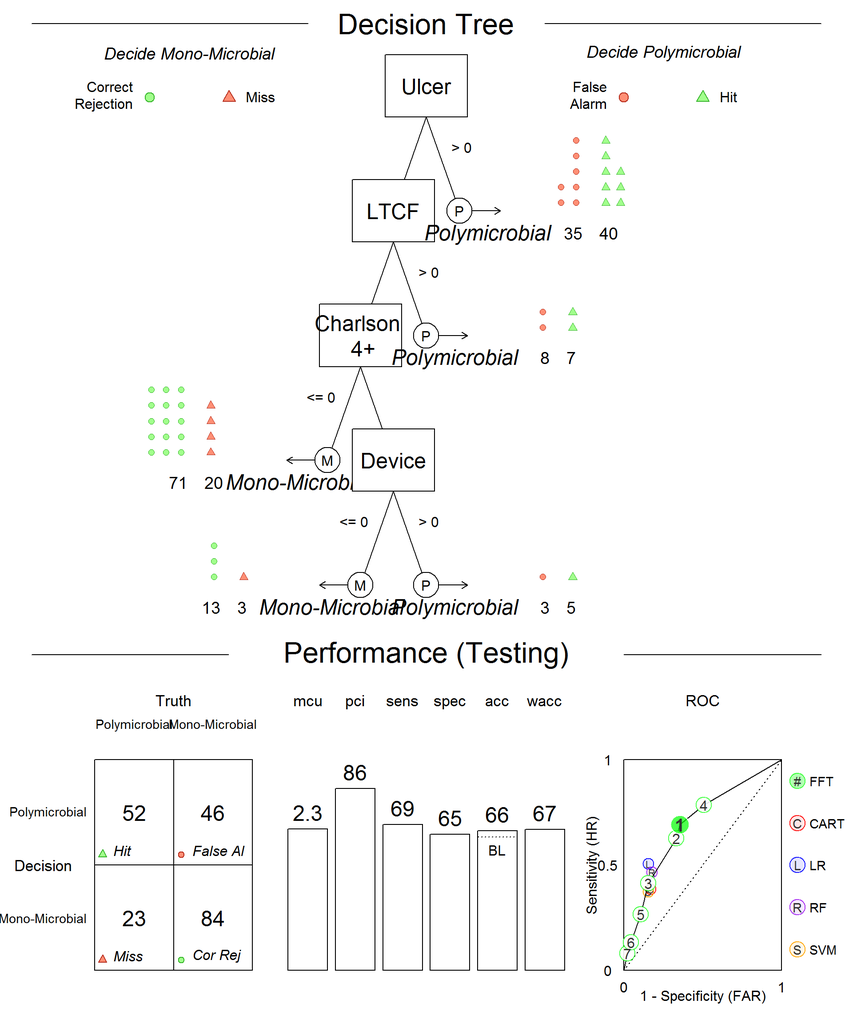

```r
plot(coinfx.fft,
     data = "test",
     cue.cex = 1.5,
     cue.labels = c("Ulcer", "LTCF", "Charlson \n 4+", "Device"),
     decision.cex = 1.5,
     show.header = FALSE,
     label.tree = "Decision Tree")
```

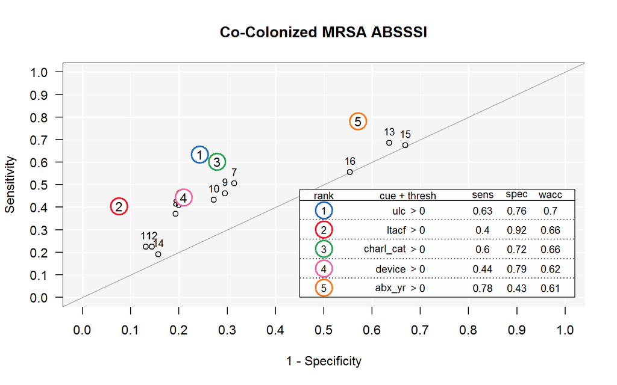

```r
plot(coinfx.fft, what = "cues")
```

```r
coinfx.fff <- FFForest(poly_infx ~ .,
                       data = rbind(main_train_num, main_test_num),
                       ntree = 100,
                       train.p = 0.5,
                       goal = "acc")
```

```
[1] "Forest of 100 ifan FFTs from 50% random training splits."
[1] "Median performance across all 100 FFTs:"
     train test
acc   0.74 0.72
bacc  0.69 0.67
wacc  0.69 0.67
sens  0.48 0.48
spec  0.88 0.86
mcu   1.74 1.72
pci   0.90 0.90
[1] "Cue Importance:"
        cue importance
1     ltacf       1.00
2       ulc       0.99
3 charl_cat       0.77
4 cssti_lev       0.37
5    device       0.36
```

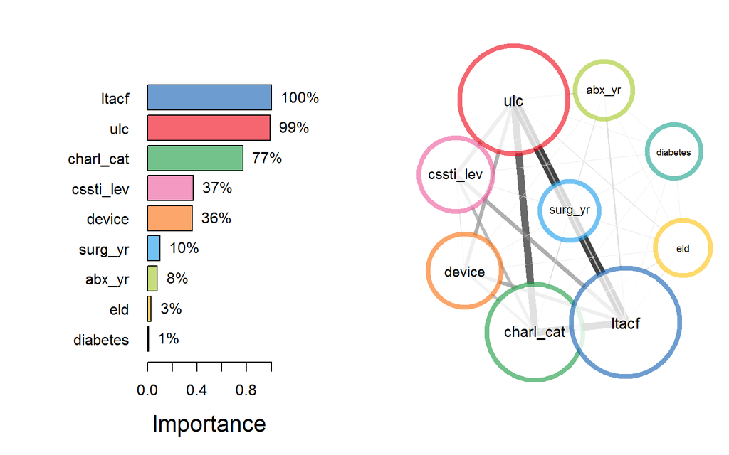

```r
plot(coinfx.fff, node.cex.lim = c(8, 16), line.cex.lim = c(0.8, 10))
```

```r
# tiff("forest_of_FFTs.tiff", height = 6, width = 14, units = "in",
#      res = 800, compression = "lzw")
# plot(coinfx.fff,
#      node.cex.lim = c(8, 16),
#      line.cex.lim = c(0.8, 10))
# dev.off()
```

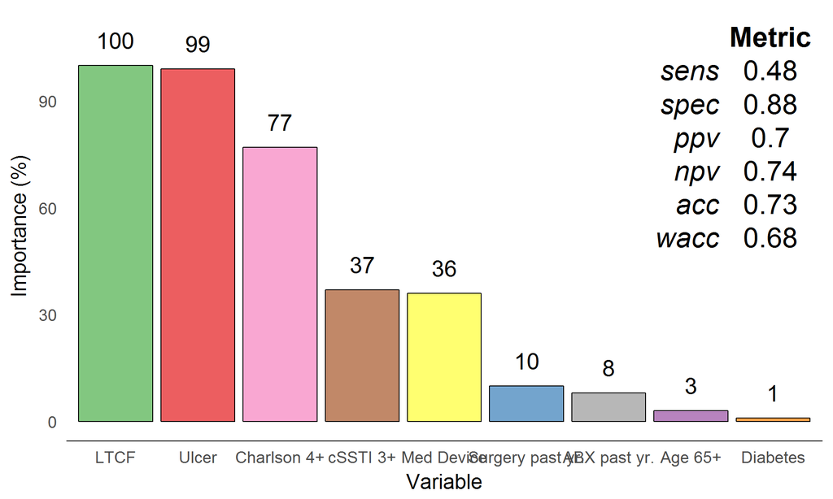

```r
labels <- c("ABX past yr.",
            "Charlson 4+",
            "cSSTI 3+",
            "Med Device",
            "Diabetes",
            "Age 65+",
            "LTCF",
            "Surgery past yr.",
            "Ulcer")

colorset <- RColorBrewer::brewer.pal(9, "Set1")

tabletheme <- gridExtra::ttheme_minimal(
  core = list(fg_params = list(cex = 2.0)),
  colhead = list(fg_params = list(cex = 2.0)),
  rowhead = list(fg_params = list(cex = 2.0))
)

confusion <- t(coinfx.fff$forest.stats$train[c(6:9, 11, 13)])
confusion <- data.frame(Metric = round(confusion, 2))

FFFimportance <- coinfx.fff$frequencies %>%
  data.frame() %>%
  mutate(Var1 = factor(Var1, labels = labels)) %>%
  ggplot(aes(x = reorder(Var1, -Freq),
             y = Freq,
             fill = Var1)) %>%
  add(geom_col(color = "black", alpha = 0.7)) %>%
  add(geom_text(aes(label = Freq), size = 7, vjust = -1)) %>%
  add(theme_trueMinimal(18)) %>%
  add(theme(legend.position = "none")) %>%
  add(scale_fill_brewer(palette = "Set1", direction = -1)) %>%
  add(labs(
    x = "Variable",
    y = "Importance (%)"
  )) %>%
  add(expand_limits(y = c(0, 110))) %>%
  add(annotation_custom(gridExtra::tableGrob(confusion,
                                             theme = tabletheme),
                        xmin = 8.5, xmax = 8.5, ymin = 60, ymax = 100))
FFFimportance
```

## Logistic regression

```r
library(h2o)
h2o.init()
```

[output not shown]

```r
predictors <- colnames(main_train)[-2]
response <- "poly_infx"
df.train <- as.h2o(main_train)
df.test <- as.h2o(main_test)
coinfx.lr <- h2o.glm(family = "binomial", x = predictors, y = response,
                     training_frame = df.train, lambda = 0,
                     compute_p_values = TRUE)
coinfx.lr@model$coefficients_table
```

```
Coefficients: glm coefficients
         names coefficients std_error   z_value  p_value
1    Intercept    -2.235700  0.350131 -6.385333 0.000000
2       male.1    -0.002437  0.232433 -0.010485 0.991634
3        eld.1    -0.550520  0.298718 -1.842946 0.065337
4      obese.1    -0.157872  0.262774 -0.600789 0.547981
5      black.1    -0.230974  0.243912 -0.946955 0.343661
6      ltacf.1     1.569249  0.323036  4.857809 0.000001
7   diabetes.1     0.575404  0.265328  2.168650 0.030109
8     kidney.1    -0.486046  0.328854 -1.478002 0.139407
9     device.1     0.303080  0.273429  1.108442 0.267671
10 charl_cat.1     0.503834  0.275054  1.831764 0.066987
11   chr_wnd.1     0.048562  0.253376  0.191660 0.848008
12   surg_yr.1     0.097517  0.265812  0.366864 0.713721
   standardized_coefficients
1                  -2.131683
2                  -0.002437
3                  -0.550520
4                  -0.157872
5                  -0.230974
6                   1.569249
7                   0.575404
8                  -0.486046
9                   0.303080
10                  0.503834
11                  0.048562
12                  0.097517
 [ reached getOption("max.print") -- omitted 5 rows ]
```

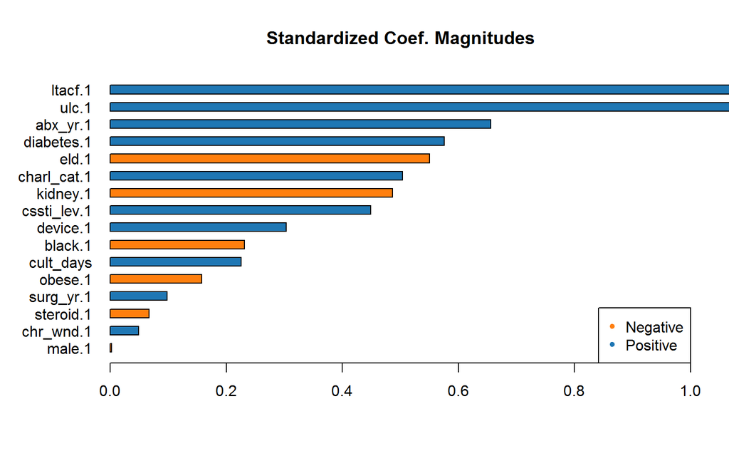

```r
h2o.std_coef_plot(coinfx.lr)
```

```r
perf <- h2o.performance(coinfx.lr, df.test)
h2o.confusionMatrix(perf)
```

```
Confusion Matrix (vertical: actual; across: predicted)  for max f1 @ threshold = 0.320859977414024:
         0  1    Error     Rate
0       92 38 0.292308  =38/130
1       26 49 0.346667   =26/75
Totals 118 87 0.312195  =64/205
```

## Gradient Boosting and Random Forest

```r
# train and cross-validate GBM
coinfx.gbm <- h2o.gbm(x = predictors, y = response,
                      training_frame = df.train,
                      distribution = "bernoulli",
                      ntrees = 10,
                      max_depth = 3,
                      min_rows = 2,
                      learn_rate = 0.2,
                      nfolds = 5,
                      fold_assignment = "Modulo",
                      keep_cross_validation_predictions = TRUE)
perf <- h2o.performance(coinfx.gbm, df.test)
h2o.confusionMatrix(perf)
```

```
Confusion Matrix (vertical: actual; across: predicted)  for max f1 @ threshold = 0.301614735374757:
         0   1    Error     Rate
0       82  48 0.369231  =48/130
1       20  55 0.266667   =20/75
Totals 102 103 0.331707  =68/205
```

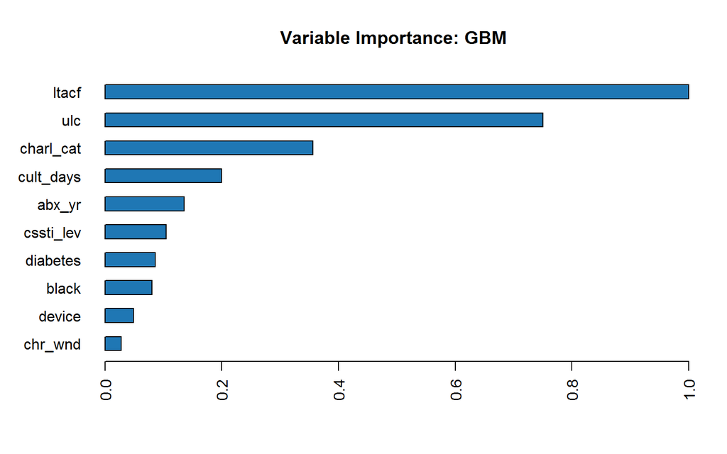

```r
h2o.varimp_plot(coinfx.gbm)
```

```r
# train and cross-validate RF
coinfx.rf <- h2o.randomForest(x = predictors, y = response,
                              training_frame = df.train,
                              ntrees = 100,
                              nfolds = 5,
                              fold_assignment = "Modulo",
                              keep_cross_validation_predictions = TRUE)
perf <- h2o.performance(coinfx.rf, df.test)
h2o.confusionMatrix(perf)
```

```
Confusion Matrix (vertical: actual; across: predicted)  for max f1 @ threshold = 0.213567459583282:
        0   1    Error     Rate
0      63  67 0.515385  =67/130
1       9  66 0.120000    =9/75
Totals 72 133 0.370732  =76/205
```

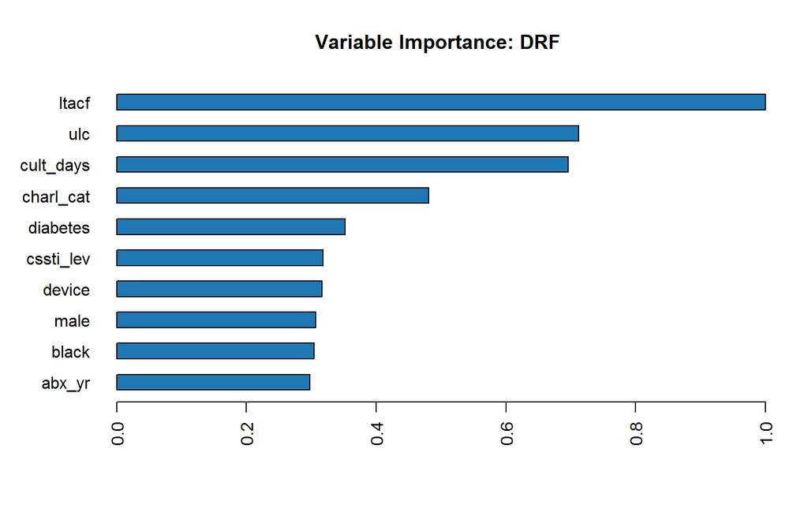

```r
h2o.varimp_plot(coinfx.rf)
```

Worse than GBM

## LASSO/Elastic-Net

```r
detach('package:FFTrees')
detach('package:purrr')
detach('package:h2o')
```

```
[1] "A shutdown has been triggered. "
```

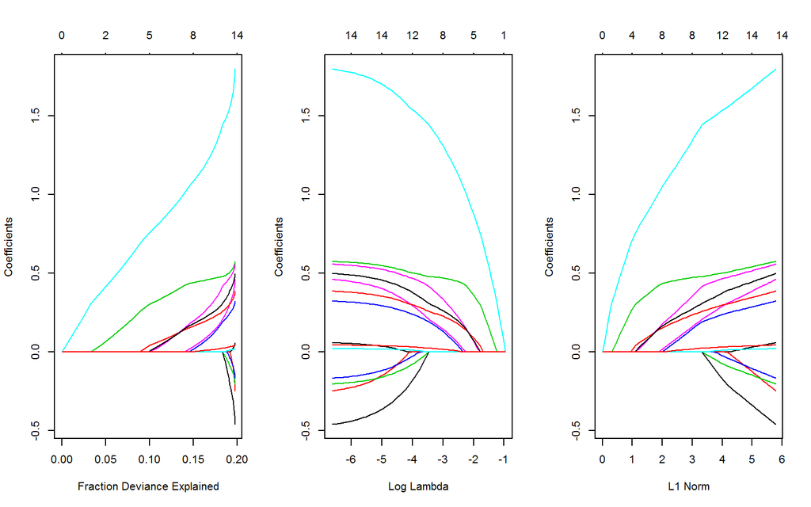

```r
library(glmnet)

y <- as.integer(main_train_num[, "poly_infx"])
x <- data.matrix(main_train_num[, c(1, 3:15)])

lasso1 <- glmnet(x = x,
                 y = y,
                 family = "binomial",
                 alpha = 0.5)

par(mfrow = c(1, 3))
plot(lasso1, xvar = "dev", label = TRUE)
plot(lasso1, xvar = "lambda", label = TRUE)
plot(lasso1, xvar = "norm", label = TRUE)
```

Copied from the *glmnet* vignette:

Prediction is a little different for logistic from Gaussian, mainly in the option type. “link” and “response” are never equivalent and “class” is only available for logistic regression. In summary,

```
* "link" gives the linear predictors
* "response" gives the fitted probabilities
* "class" produces the class label corresponding to the maximum probability.
* "coefficients" computes the coefficients at values of s
* "nonzero" retuns a list of the indices of the nonzero coefficients for each value of s.
```

For “binomial” models, results (“link”, “response”, “coefficients”, “nonzero”) are returned only for the class corresponding to the second level of the factor response.

Making predictions at class labels of $\lambda \in \left\{0.05, 0.01\right\}$ where $\lambda$ is the regularization parameter, that which controls the overall strength of the penalty. The penalty determines coefficient ‘shrinkage’ to zero and serves as our selection mechanism.

```r
pred1 <- predict(lasso1,
                 newx = data.matrix(main_test_num[, c(1, 3:15)]),
                 type = "class",
                 s = c(0.05, 0.01))

pred.tab <- table(main_test_num[,"poly_infx"], as.numeric(pred1[, 1]))
pred.tab
```

```
      0   1
  0 112  18
  1  52  23
```

accuracy with $\lambda = 0.05$ 65.85%.

```r
pred.tab <- table(main_test_num[,"poly_infx"], as.numeric(pred1[, 2]))
pred.tab
```

```
      0   1
  0 111  19
  1  48  27
```

accuracy with $\lambda = 0.01$ is 67.32%.

Cross-Valdiation with 10-folds using misclassification error as the criterion:

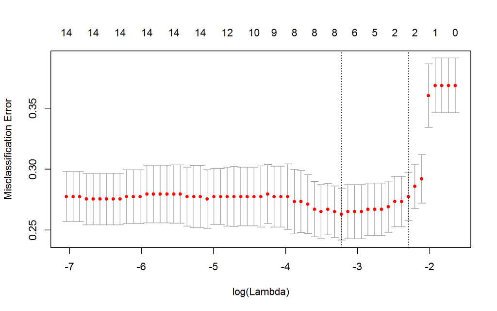

```r
lasso.cv <- cv.glmnet(x = x, y = y, family = "binomial", type.measure = "class")
plot(lasso.cv)
```

```r
coef(lasso.cv, s = "lambda.1se")
```

```
15 x 1 sparse Matrix of class "dgCMatrix"
                     1
(Intercept) -0.8204634
male         .
eld          .
obese        .
black        .
ltacf        0.8712344
diabetes     .
kidney       .
device       .
charl_cat    0.2414408
chr_wnd      .
surg_yr      .
abx_yr       .
cssti_lev    .
cult_days    .
```

```r
pred2 <- predict(lasso.cv,
                 newx = data.matrix(main_test_num[, c(1, 3:15)]),
                 type = "class",
                 s = "lambda.1se")
pred.tab <- table(main_test_num[,"poly_infx"], as.numeric(pred2[, 1]))
pred.tab
```

```
      0   1
  0 114  16
  1  53  22
```

Cross-Valdiation with 10-folds using AUC as the criterion (ROC curve):

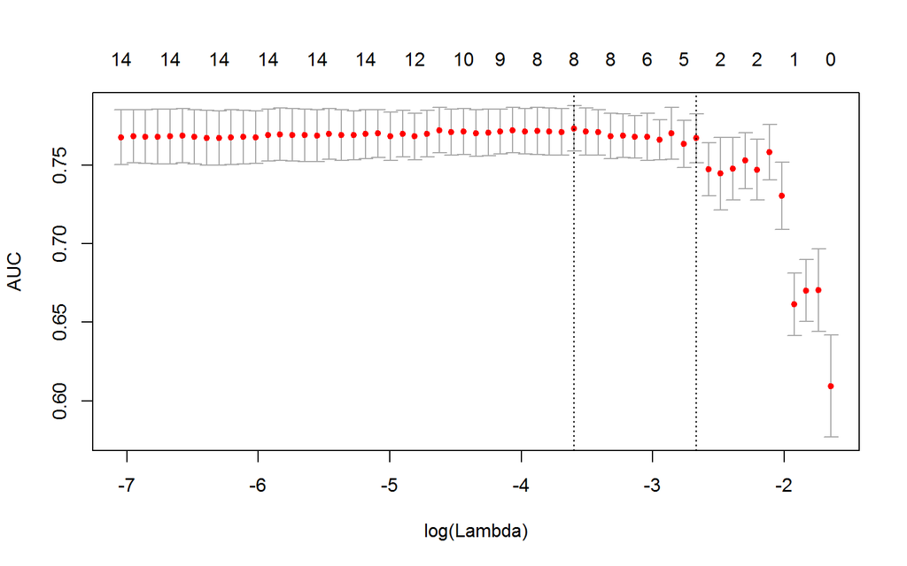

```r
lasso.cv <- cv.glmnet(x = x, y = y, family = "binomial", type.measure = "auc")
plot(lasso.cv)
```

# Outcome modelling

Table 4 in Evans **et al.**

Univariate

```r
outcomes <- c("read_30", "new_icu", "new_int",
              "new_surg", "new_cvc", "new_uc", "dth_30")
outcome.df <- main %>%
  mutate_at(vars(outcomes), funs(as.numeric)) %>%
  mutate_at(vars(outcomes), funs(. - 1)) %>%
  as.data.frame()

psych::describe(main$los)
```

```
   vars   n  mean    sd median trimmed  mad min max range skew kurtosis
X1    1 688 10.52 15.81      6    7.42 4.45   1 238   237 6.34    68.77
    se
X1 0.6
```

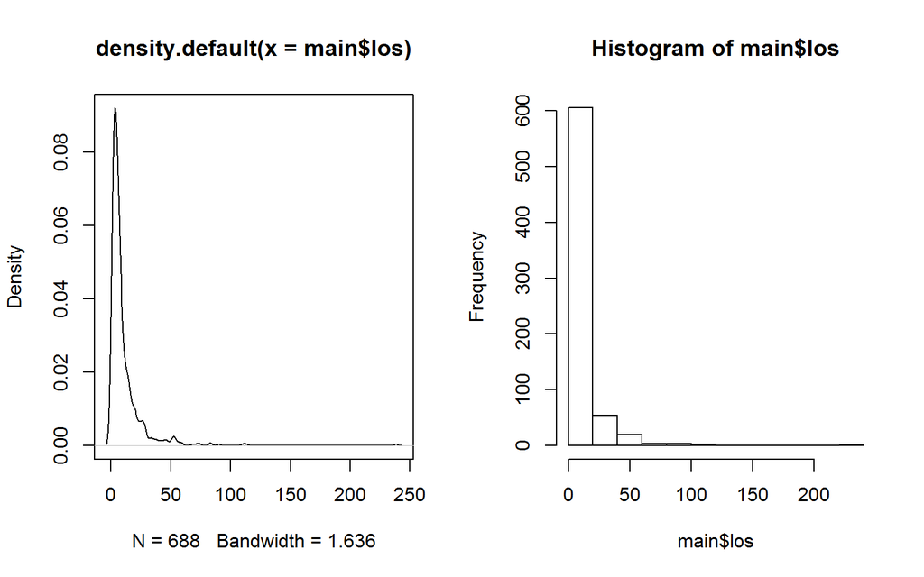

```r
par(mfrow = c(1, 2))
plot(density(main$los)); hist(main$los)
```

Trying negative binomial regression

```r
library(MASS)
los_nb <- glm.nb(los ~ poly_infx, data = main)
summary(los_nb)
```

```
Call:
glm.nb(formula = los ~ poly_infx, data = main, init.theta = 1.282333915,
    link = log)

Deviance Residuals:
    Min       1Q   Median       3Q      Max
-1.9119  -1.0265  -0.5506   0.0689   5.2920

Coefficients:
            Estimate Std. Error z value Pr(>|z|)
(Intercept)  2.01444    0.04582   43.97   <2e-16 ***
poly_infx1   0.73995    0.07371   10.04   <2e-16 ***
---
Signif. codes:  0 '***' 0.001 '**' 0.01 '*' 0.05 '.' 0.1 ' ' 1

(Dispersion parameter for Negative Binomial(1.2823) family taken to be 1)

    Null deviance: 828.31  on 687  degrees of freedom
Residual deviance: 723.74  on 686  degrees of freedom
AIC: 4580.7

Number of Fisher Scoring iterations: 1

              Theta:  1.2823
          Std. Err.:  0.0722

 2 x log-likelihood:  -4574.6580
```

```r
test <- glm(los ~ poly_infx, family = "poisson", data = main)
pchisq(2 * (logLik(los_nb) - logLik(test)), df = 1, lower.tail = FALSE)
```

```
'log Lik.' 0 (df=3)
```

```r
RR <- exp(cbind(estimate = coef(los_nb), confint(los_nb)))
RR
```

```
            estimate    2.5 %   97.5 %
(Intercept) 7.496552 6.859094 8.208885
poly_infx1  2.095825 1.815164 2.423496
```

having a polymicrobial MRSA ABSSSI increases the expected log count of the number of days in the hospital by 0.74 vs.a mono-microbial MRSA ABSSSI.

As for fit, check the poisson model,

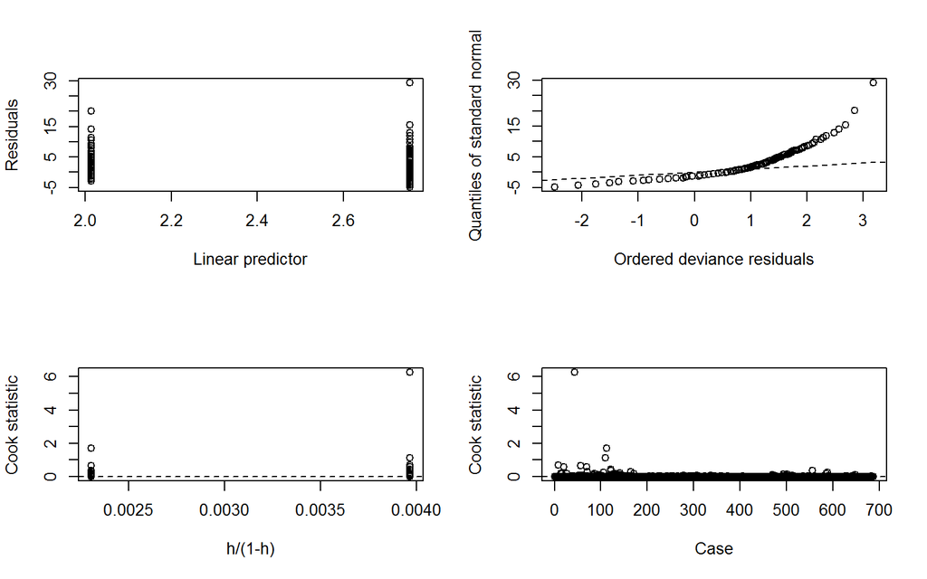

```r
boot::glm.diag.plots(test)
```

Against the negative binomial model,

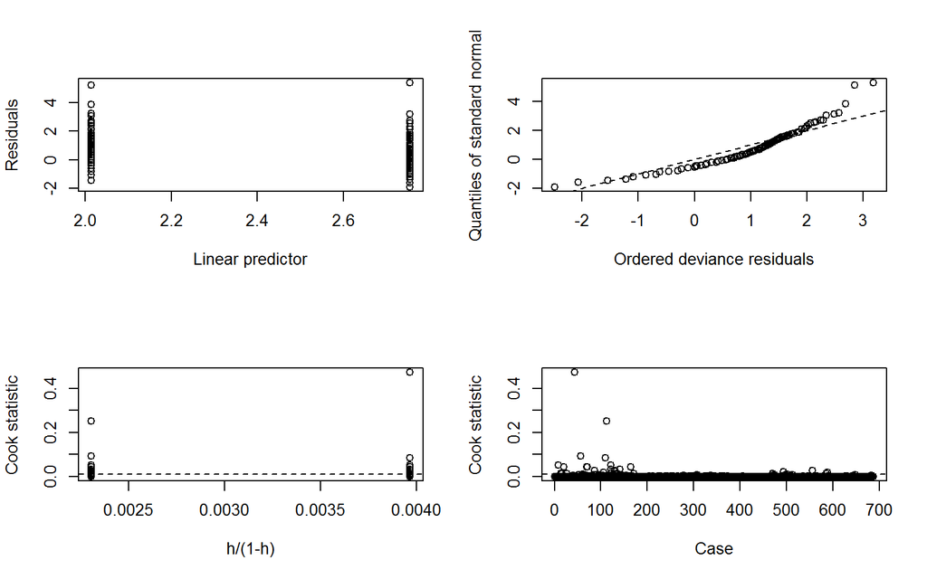

```r
boot::glm.diag.plots(los_nb)
```

Much better fit.

```r
los_nb <- glm.nb(los ~ poly_infx + age + chr_wnd + charl_cat + cssti_lev,
                 data = main)
summary(los_nb)
```

```
Call:
glm.nb(formula = los ~ poly_infx + age + chr_wnd + charl_cat +
    cssti_lev, data = main, init.theta = 1.638258307, link = log)

Deviance Residuals:
    Min       1Q   Median       3Q      Max
-2.0271  -0.9239  -0.4561   0.1788   4.4841

Coefficients:
             Estimate Std. Error z value Pr(>|z|)
(Intercept)  1.502550   0.107911  13.924  < 2e-16 ***
poly_infx1   0.474637   0.071594   6.630 3.37e-11 ***
age          0.003850   0.002067   1.862   0.0626 .
chr_wnd1    -0.113881   0.071902  -1.584   0.1132
charl_cat1   0.402849   0.077723   5.183 2.18e-07 ***
cssti_lev1   0.733247   0.078280   9.367  < 2e-16 ***
---
Signif. codes:  0 '***' 0.001 '**' 0.01 '*' 0.05 '.' 0.1 ' ' 1

(Dispersion parameter for Negative Binomial(1.6383) family taken to be 1)

    Null deviance: 991.19  on 677  degrees of freedom
Residual deviance: 690.12  on 672  degrees of freedom
  (10 observations deleted due to missingness)
AIC: 4356.1

Number of Fisher Scoring iterations: 1

              Theta:  1.6383
          Std. Err.:  0.0983

 2 x log-likelihood:  -4342.1160
```

```r
test <- glm(los ~ poly_infx + age + chr_wnd + charl_cat + cssti_lev,
            family = "poisson",
            data = main)
pchisq(2 * (logLik(los_nb) - logLik(test)), df = 1, lower.tail = FALSE)
```

```
'log Lik.' 0 (df=7)
```

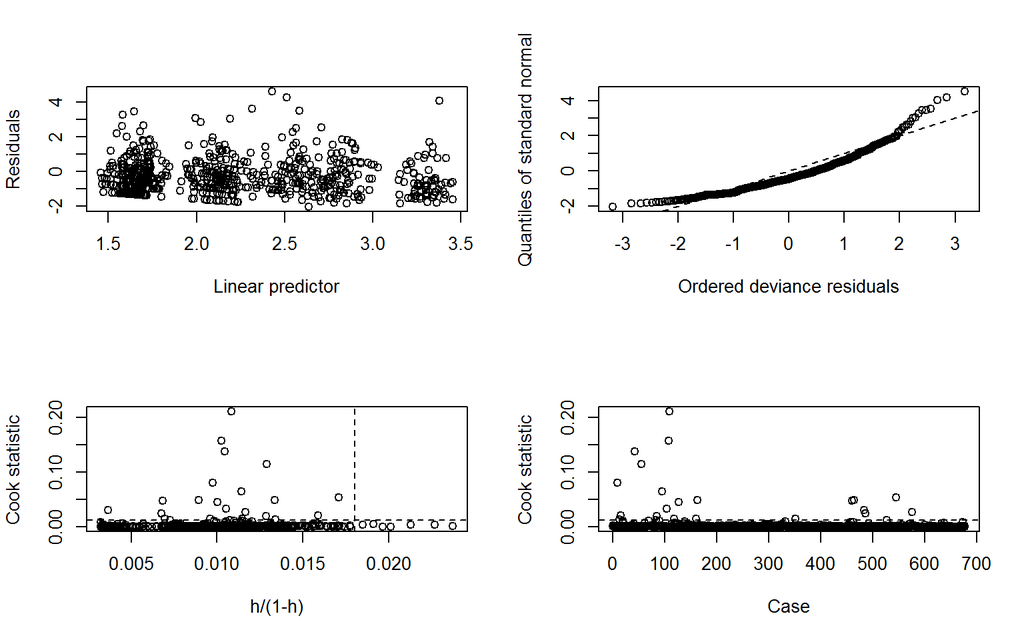

```r
boot::glm.diag.plots(los_nb)
```

```r
RR <- exp(cbind(estimate = coef(los_nb), confint(los_nb)))
RR
```

```
             estimate     2.5 %   97.5 %
(Intercept) 4.4931335 3.5935394 5.626273
poly_infx1  1.6074305 1.4007465 1.846156
age         1.0038570 0.9996109 1.008143
chr_wnd1    0.8923644 0.7771707 1.025885
charl_cat1  1.4960806 1.2863932 1.740448
cssti_lev1  2.0818301 1.7980857 2.415695
```

```r
rm(los_nb, test, RR)
detach('package:MASS')
```

```r
lapply(outcome.df[, outcomes],
       function(var) {
         mod <- glm(var ~ poly_infx, data = outcome.df, family = binomial)
         OR <- exp(mod$coefficients)
         CI <- exp(confint(mod))
         cbind(OR, CI)
       })
```

```
$read_30
                   OR     2.5 %    97.5 %
(Intercept) 0.1748634 0.1329164 0.2262717
poly_infx1  2.3585805 1.6133214 3.4576188

$new_icu
                   OR      2.5 %    97.5 %
(Intercept) 0.1308901 0.09633167 0.1739209
poly_infx1  3.1584358 2.12285698 4.7343703

$new_int
                   OR      2.5 %    97.5 %
(Intercept) 0.1217617 0.08881699 0.1629693
poly_infx1  2.1763830 1.41907400 3.3481964

$new_surg
                   OR     2.5 %    97.5 %
(Intercept) 2.9009009 2.3463440 3.6138126
poly_infx1  0.6935448 0.4942982 0.9745855

$new_cvc
                   OR     2.5 %   97.5 %
(Intercept) 0.2676923 0.2100904 0.337421
poly_infx1  2.8218804 1.9979569 3.999273

$new_uc
                    OR     2.5 %    97.5 %
(Intercept) 0.09495549 0.0648104 0.1341579
poly_infx1  4.23985390 2.6762954 6.8321372

$dth_30
                    OR      2.5 %     97.5 %
(Intercept) 0.04187192 0.02477957 0.06579598
poly_infx1  4.36312217 2.44282275 8.10289414
```

Table 5 in Evans **et al.**

Multivariate Outcomes

```r
lapply(outcome.df[, outcomes],
       function(var) {
         mod <- glm(var ~ poly_infx + age + chr_wnd + charl_cat + cssti_lev,
                    data = outcome.df,
                    family = binomial)
         n <- length(mod$residuals)
         prop <- round((n / 688) * 100, 2)
         OR <- exp(mod$coefficients)
         CI <- exp(confint(mod))
         cbind(OR, CI, n, prop)
       })
```

```
$read_30
                   OR      2.5 %    97.5 %   n  prop
(Intercept) 0.1393404 0.07180071 0.2639438 671 97.53
poly_infx1  1.7933233 1.19248337 2.6978168 671 97.53
age         0.9983987 0.98615344 1.0106573 671 97.53
chr_wnd1    1.2831315 0.85101303 1.9227339 671 97.53
charl_cat1  1.7011541 1.08905511 2.6648427 671 97.53
cssti_lev1  1.4159881 0.91061319 2.1851721 671 97.53

$new_icu
                    OR      2.5 %    97.5 %   n  prop
(Intercept) 0.06427979 0.02957677 0.1342670 675 98.11
poly_infx1  2.14902263 1.37121009 3.3799750 675 98.11
age         1.00425451 0.99056288 1.0180693 675 98.11
chr_wnd1    0.40239374 0.24062139 0.6563456 675 98.11
charl_cat1  2.04747328 1.25739002 3.3541892 675 98.11
cssti_lev1  4.80641835 3.04065564 7.6608430 675 98.11

$new_int
                    OR      2.5 %    97.5 %   n  prop
(Intercept) 0.06858654 0.03122369 0.1446337 676 98.26
poly_infx1  1.60188450 1.00168551 2.5610676 676 98.26
age         1.00820548 0.99418564 1.0223969 676 98.26
chr_wnd1    0.48872254 0.28768937 0.8063414 676 98.26
charl_cat1  1.60231900 0.96446502 2.6735945 676 98.26
cssti_lev1  2.10751641 1.29087086 3.4280104 676 98.26

$new_surg
                   OR     2.5 %     97.5 %   n  prop
(Intercept) 5.6773178 3.2477563 10.1000662 676 98.26
poly_infx1  0.7750228 0.5381356  1.1186253 676 98.26
age         0.9882973 0.9778676  0.9987746 676 98.26
chr_wnd1    0.7962029 0.5547840  1.1471653 676 98.26
charl_cat1  0.9544353 0.6428598  1.4208148 676 98.26
cssti_lev1  1.0769134 0.7183815  1.6290288 676 98.26

$new_cvc
                   OR      2.5 %    97.5 %   n prop
(Intercept) 0.1745210 0.09428122 0.3167021 646 93.9
poly_infx1  1.8794134 1.28328073 2.7502406 646 93.9
age         0.9977908 0.98638236 1.0092148 646 93.9
chr_wnd1    1.4055747 0.95555297 2.0586997 646 93.9
charl_cat1  1.9919609 1.31456223 3.0237007 646 93.9
cssti_lev1  2.6160586 1.74809324 3.9152750 646 93.9

$new_uc
                    OR       2.5 %     97.5 %   n  prop
(Intercept) 0.02256657 0.008646954 0.05488752 576 83.72
poly_infx1  2.66915375 1.615604363 4.45685800 576 83.72
age         1.02001378 1.004391537 1.03612433 576 83.72
chr_wnd1    0.70789363 0.411428490 1.19231702 576 83.72
charl_cat1  1.64798390 0.965168322 2.82304495 576 83.72
cssti_lev1  3.23637538 1.936636551 5.42155132 576 83.72

$dth_30
                      OR        2.5 %      97.5 %   n  prop
(Intercept) 0.0008631787 0.0001664635 0.003636667 659 95.78
poly_infx1  2.1741688131 1.1456555707 4.238436268 659 95.78
age         1.0561405975 1.0341780845 1.080046812 659 95.78
chr_wnd1    0.7935531808 0.4119105372 1.496558902 659 95.78
charl_cat1  2.3543090005 1.1625553414 5.027503341 659 95.78
cssti_lev1  3.0085897001 1.5847243961 5.812045481 659 95.78
```

Stratifying/adjusting this analysis by ABSSSI site

```r
# reduce sites to simpler categories
main.sites <- main %>%
  mutate(
    site = ifelse(site1 == 'Head', 'Upper Body', site1),
    site = ifelse(site == 'Hand', 'Upper Extremity', site),
    site = ifelse(site == 'Rectal', 'Buttock', site),
    site = ifelse(site == 'Foot', 'Lower Extremity', site),
    site = ifelse(site %in% c('Blood', 'Respiratory'), 'Unknown', site)
  ) %>%
  mutate_at(vars(outcomes), funs(as.numeric)) %>%
  mutate_at(vars(outcomes), funs(. - 1)) %>%
  filter(site != 'Unknown') %>%
  as.data.frame()

table(main.sites$site)
```

```
           Abdomen     Back and Sides            Buttock
                59                 63                100
Groin and Genitals    Lower Extremity         Upper Body
                62                221                 77
   Upper Extremity
                87
```

```r
dim(main.sites)
```

```
[1] 669 204
```

```r
lapply(main.sites[, outcomes],
       function(var) {
         mod <- glm(var ~ poly_infx + age + chr_wnd + charl_cat + cssti_lev + site,
                    data = main.sites,
                    family = binomial)
         n <- length(mod$residuals)
         prop <- round((n / 688) * 100, 2)
         OR <- exp(mod$coefficients)
         CI <- exp(confint(mod))
         cbind(OR, CI, n, prop)
       })
```

```
$read_30
                              OR      2.5 %    97.5 %   n  prop
(Intercept)            0.2085212 0.08267154 0.5040034 652 94.77
poly_infx1             1.6555326 1.08483184 2.5246570 652 94.77
age                    0.9973132 0.98462541 1.0100126 652 94.77
chr_wnd1               1.3080199 0.84493396 2.0150863 652 94.77
charl_cat1             1.7212658 1.09263869 2.7198927 652 94.77
cssti_lev1             1.4732508 0.93599723 2.3018698 652 94.77
siteBack and Sides     0.6516751 0.25584585 1.6254861 652 94.77
siteButtock            0.8230684 0.37900096 1.8272544 652 94.77
siteGroin and Genitals 0.7276720 0.28670491 1.8106437 652 94.77
siteLower Extremity    0.7769807 0.38653008 1.6227460 652 94.77
siteUpper Body         0.4126524 0.15044908 1.0685765 652 94.77
siteUpper Extremity    0.5811565 0.23804688 1.4003656 652 94.77

$new_icu
                               OR      2.5 %    97.5 %   n  prop
(Intercept)            0.07963602 0.02624368 0.2251137 656 95.35
poly_infx1             2.13548840 1.32394128 3.4577103 656 95.35
age                    1.00150994 0.98701785 1.0160940 656 95.35
chr_wnd1               0.42025566 0.24244441 0.7106750 656 95.35
charl_cat1             2.42141563 1.45421703 4.0710403 656 95.35
cssti_lev1             4.55272751 2.80514868 7.4553732 656 95.35
siteBack and Sides     1.26843963 0.46492402 3.5029748 656 95.35
siteButtock            1.36252791 0.58192516 3.3362613 656 95.35
siteGroin and Genitals 0.52269876 0.16351206 1.5826961 656 95.35
siteLower Extremity    0.63042514 0.27747438 1.5021729 656 95.35
siteUpper Body         0.64914124 0.21760293 1.8752163 656 95.35
siteUpper Extremity    0.72777226 0.26227801 2.0055831 656 95.35

$new_int
                              OR      2.5 %    97.5 %   n  prop
(Intercept)            0.1165374 0.04027478 0.3162881 657 95.49
poly_infx1             1.4455951 0.87954508 2.3724324 657 95.49
age                    1.0054845 0.99093797 1.0201845 657 95.49
chr_wnd1               0.4594593 0.26089747 0.7854624 657 95.49
charl_cat1             1.7389700 1.03026136 2.9524201 657 95.49
cssti_lev1             1.8783128 1.12374769 3.1216476 657 95.49
siteBack and Sides     0.5928379 0.19767146 1.6810716 657 95.49
siteButtock            1.3053484 0.58110025 3.0687553 657 95.49
```

[output cut: 49 more lines]

```

$dth_30
                                 OR        2.5 %       97.5 %   n  prop
(Intercept)            0.0004837538 4.196122e-05  0.003631902 641 93.17
poly_infx1             1.9694639861 9.822112e-01  4.067481658 641 93.17
age                    1.0542699321 1.030916e+00  1.079810678 641 93.17
chr_wnd1               0.7862069149 3.829117e-01  1.585925300 641 93.17
charl_cat1             2.3003383738 1.096155e+00  5.116648888 641 93.17
cssti_lev1             2.4826979520 1.249280e+00  4.997165852 641 93.17
siteBack and Sides     1.8355743162 3.163694e-01 14.445945739 641 93.17
siteButtock            2.9826333133 7.049643e-01 20.628366458 641 93.17
siteGroin and Genitals 2.4188064423 3.586445e-01 20.159907479 641 93.17
siteLower Extremity    2.4335497471 6.239236e-01 16.202429619 641 93.17
siteUpper Body         2.0171524166 2.902531e-01 17.130898737 641 93.17
siteUpper Extremity    0.6845080455 3.015319e-02  7.811251116 641 93.17
```

## Stratified analysis

Subsets analysis

```r
site_cats <- unique(main.sites$site)
stratLogit <- function(var) {
  form <- as.formula(paste0(var, "~ poly_infx+age+chr_wnd+charl_cat+cssti_lev"))
  models <- vector("list", length(site_cats))
  for (i in 1:length(site_cats)) {
    name <- site_cats[i]
    mod <- glm(formula = form,
               data = main.sites,
               subset = (site == site_cats[i]),
               family = binomial)
    n <- length(mod$residuals)
    prop <- round((n / 688) * 100, 2)
    OR <- round(exp(mod$coefficients)[2], 2)
    LB <- round(as.numeric(exp(confint(mod))[2, 1]), 2)
    UB <- round(as.numeric(exp(confint(mod))[2, 2]), 2)
    models[[i]] <- cbind(OR, LB, UB, n, prop)
  }
  models <- do.call(rbind, models)
  row.names(models) <- site_cats
  return(models)
}

modelLists <- vector("list", length(outcomes))
for(i in 1:length(outcomes)) {
  modelLists[[i]] <- stratLogit(outcomes[i])
}
names(modelLists) <- outcomes

modelLists
```

```
$read_30
                     OR   LB    UB   n  prop
Buttock            1.27 0.44  3.70  98 14.24
Lower Extremity    2.02 1.02  4.06 212 30.81
Upper Extremity    1.14 0.22  4.76  86 12.50
Groin and Genitals 5.25 0.97 33.42  62  9.01
Upper Body         0.28 0.01  2.19  75 10.90
Back and Sides     5.43 0.97 37.55  61  8.87
Abdomen            1.51 0.41  5.51  58  8.43

$new_icu
                      OR   LB     UB   n  prop
Buttock             4.24 1.47  13.47  99 14.39
Lower Extremity     2.11 0.91   5.08 215 31.25
Upper Extremity    13.60 2.52 103.50  86 12.50
Groin and Genitals  2.49 0.27  23.58  62  9.01
Upper Body          9.75 1.14 210.23  75 10.90
Back and Sides      0.81 0.10   5.54  61  8.87
Abdomen             0.13 0.01   1.21  58  8.43

$new_int
                      OR   LB           UB   n  prop
Buttock             3.08 1.05  9.81000e+00  99 14.39
Lower Extremity     1.52 0.66  3.59000e+00 216 31.40
Upper Extremity    12.41 1.24  3.10490e+02  86 12.50
Groin and Genitals  1.79 0.26  1.11700e+01  62  9.01
Upper Body          1.35 0.16  8.59000e+00  74 10.76
Back and Sides      0.00   NA 1.08488e+186  62  9.01
Abdomen             0.54 0.10  2.33000e+00  58  8.43

$new_surg
                     OR   LB     UB   n  prop
Buttock            0.44 0.14   1.28  99 14.39
Lower Extremity    0.96 0.52   1.77 215 31.25
Upper Extremity    0.52 0.16   1.80  86 12.50
Groin and Genitals 0.47 0.11   2.06  62  9.01
Upper Body         5.29 0.78 109.85  75 10.90
Back and Sides     3.47 0.72  21.89  62  9.01
Abdomen            0.50 0.09   2.88  58  8.43

```

[output cut: 14 more lines]

```
Upper Extremity    9.69 0.64 385.54  83 12.06
Groin and Genitals 1.82 0.19  15.03  51  7.41
Upper Body         0.40 0.01   6.92  63  9.16
Back and Sides     7.03 1.21  51.25  56  8.14
Abdomen            4.66 0.82  32.02  47  6.83

$dth_30
                      OR   LB            UB   n  prop
Buttock             2.16 0.39  1.697000e+01  97 14.10
Lower Extremity     2.55 0.92  7.910000e+00 213 30.96
Upper Extremity     0.00 0.00           Inf  85 12.35
Groin and Genitals 12.55 0.50  1.091050e+03  62  9.01
Upper Body          0.00   NA 9.891547e+282  71 10.32
Back and Sides      6.98 0.23  2.226430e+03  59  8.58
Abdomen             2.60 0.00            NA  54  7.85
```

Firth’s logistic regression to handle sparsity/separation between predictor and outcome

```r
library(logistf)

stratLogistf <- function(var) {
  form <- as.formula(paste0(var, "~ poly_infx+age+chr_wnd+charl_cat+cssti_lev"))
  models <- vector("list", length(site_cats))
  for (i in 1:length(site_cats)) {
    name <- site_cats[i]
    mod <- logistf(formula = form,
                   data = main.sites[main.sites$site == site_cats[i], ])
    n <- mod$n
    prop <- round((n / 688) * 100, 2)
    OR <- round(exp(mod$coefficients)[2], 2)
    LB <- round(as.numeric(exp(confint(mod))[2, 1]), 2)
    UB <- round(as.numeric(exp(confint(mod))[2, 2]), 2)
    models[[i]] <- cbind(OR, LB, UB, n, prop)
  }
  models <- do.call(rbind, models)
  row.names(models) <- site_cats
  return(models)
}

modelLists <- vector("list", length(outcomes))
for(i in 1:length(outcomes)) {
  modelLists[[i]] <- stratLogistf(outcomes[i])
}
names(modelLists) <- outcomes

modelLists
```

```
$read_30
                     OR   LB    UB   n  prop
Buttock            1.26 0.46  3.51  98 14.24
Lower Extremity    1.98 1.01  3.92 212 30.81
Upper Extremity    1.23 0.27  4.57  86 12.50
Groin and Genitals 4.18 0.90 22.18  62  9.01
Upper Body         0.43 0.04  2.54  75 10.90
Back and Sides     4.24 0.89 23.96  61  8.87
Abdomen            1.48 0.44  4.93  58  8.43

$new_icu
                     OR   LB    UB   n  prop
Buttock            3.84 1.39 11.56  99 14.39
Lower Extremity    2.03 0.90  4.77 215 31.25
Upper Extremity    9.50 2.11 55.26  86 12.50
Groin and Genitals 2.20 0.31 15.21  62  9.01
Upper Body         6.19 1.00 64.16  75 10.90
Back and Sides     0.89 0.14  4.95  61  8.87
Abdomen            0.26 0.02  1.62  58  8.43

$new_int
                     OR   LB    UB   n  prop
Buttock            2.85 1.02  8.62  99 14.39
Lower Extremity    1.49 0.66  3.45 216 31.40
Upper Extremity    7.33 1.11 79.53  86 12.50
Groin and Genitals 1.72 0.31  8.96  62  9.01
Upper Body         1.50 0.23  7.85  74 10.76
Back and Sides     0.04 0.00  0.64  62  9.01
Abdomen            0.64 0.15  2.41  58  8.43

$new_surg
                     OR   LB    UB   n  prop
Buttock            0.46 0.16  1.29  99 14.39
Lower Extremity    0.96 0.53  1.75 215 31.25
Upper Extremity    0.53 0.17  1.70  86 12.50
Groin and Genitals 0.51 0.13  2.00  62  9.01
Upper Body         3.39 0.65 35.40  75 10.90
Back and Sides     2.77 0.65 15.02  62  9.01
Abdomen            0.52 0.11  2.45  58  8.43

```

[output cut: 14 more lines]

```
Upper Extremity    5.28 0.61 67.37  83 12.06
Groin and Genitals 1.73 0.25 10.98  51  7.41
Upper Body         0.70 0.04  6.60  63  9.16
Back and Sides     5.17 1.08 28.82  56  8.14
Abdomen            3.79 0.81 20.11  47  6.83

$dth_30
                     OR   LB    UB   n  prop
Buttock            1.95 0.40 12.01  97 14.10
Lower Extremity    2.37 0.89  6.96 213 30.96
Upper Extremity    0.65 0.00 13.46  85 12.35
Groin and Genitals 4.41 0.42 62.50  62  9.01
Upper Body         0.39 0.00  5.97  71 10.32
Back and Sides     2.31 0.22 53.05  59  8.58
Abdomen            1.33 0.07 33.82  54  7.85
```

## Severity of outcomes vs. polymicrobial frequency

```r
psych::describe(main$org_sum)
```

```
   vars   n mean   sd median trimmed  mad min max range skew kurtosis   se
X1    1 253 2.12 1.47      2    1.85 1.48   1  11    10 2.16     6.78 0.09
```

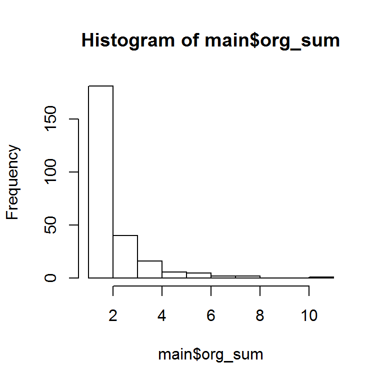

```r
hist(main$org_sum)
```

The median number of organisms in polymicrobial wounds was 2, ranging from 1 to 11.

How do the odds of our outcomes change as the number of organisms in the wound increase?

```r
models <- lapply(outcome.df[, outcomes],
                 function(var) {
                   mod <- glm(var ~ org_sum,
                              data = outcome.df,
                              family = binomial,
                              subset = (poly_infx == 1))
                   OR <- exp(coefficients(mod)[2])
                   CI <- exp(confint(mod)[2, ])
                   c(colnames(var), OR, CI)
                   }
                 )
models
```

```
$read_30
  org_sum     2.5 %    97.5 %
0.8359653 0.6625408 1.0236432

$new_icu
  org_sum     2.5 %    97.5 %
1.0345939 0.8569757 1.2355918

$new_int
  org_sum     2.5 %    97.5 %
1.1121973 0.9111157 1.3421793

$new_surg
  org_sum     2.5 %    97.5 %
1.0550245 0.8829564 1.2810563

$new_cvc
  org_sum     2.5 %    97.5 %
1.0423243 0.8776929 1.2376556

$new_uc
  org_sum     2.5 %    97.5 %
1.1221453 0.9301639 1.3500541

$dth_30
  org_sum     2.5 %    97.5 %
1.1592025 0.9333042 1.4183167
```

It really doesn’t affect the occurrence of each individual outcome. What about the number of individual outcomes as an indicator of severity?

```r
temp <- outcome.df %>%
  mutate(sum_outcomes = rowSums(.[c(171, 194, 93:95, 97:98)])) %>%
  filter(!is.na(sum_outcomes))

test <- glm(sum_outcomes ~ org_sum, data = temp)
exp(coefficients(test))
```

```
(Intercept)     org_sum
   9.357819    1.047423
```

```r
exp(confint(test))
```

```
                2.5 %   97.5 %
(Intercept) 6.4493123 13.57800
org_sum     0.9094643  1.20631
```

The answer is … no. No, there is not any indication that, with more microbes inhabiting a polymicrobial MRSA ABSSSI, there will be more severe outcomes or more ‘adverse’ outcomes. Perhaps because all of these infections already have MRSA in them. Yeah, that’s probably it.

# Misc. Functions

```r
# function to generate heatmaps for our specific needs
# requires ggplot2, magrittr
#' @param df data.frame object holding variables x, y, and fill
#' @param x vector of character or factor values for the x axis
#' @param y vector of character or factor values for the y axis
#' @param fill vector of numeric values for heat intensities
#' @param xlab label for x-axis
#' @param barheight height of the guide legend bar
#' @param barwidth width of the guide legend bar
#' @param legend_top position guide legend at top of heatmap
#' @param angle angle of x-axis ticks
#' @param yremove if TRUE, remove all y axis items

heatMap <- function(df, x, y, fill, xlab,
                    barheight = NULL, barwidth = NULL,
                    legend_top = FALSE,
                    angle = TRUE,
                    yremove = FALSE) {
  heat <- df %>%
    ggplot(aes_string(x = x, y = y, fill = fill)) %>%
    add(geom_tile()) %>%
    add(scale_fill_gradient(low = "navyblue",
                            high = "darkorange1")) %>%
    add(theme_minimal(14)) %>%
    add(scale_y_discrete(limits = rev(levels(df$variable)))) %>%
    add(labs(
      x = xlab,
      y = "",
      fill = "Proportion"
    ))
  if (angle)
    heat <- heat + theme(
      axis.text.x = element_text(angle = 45,
                                 hjust = 1,
                                 face = "bold")
    )
  if (legend_top)
    heat <- heat +
      theme(legend.position = "top") +
      guides(fill = guide_colorbar(barwidth = barwidth,
                                   barheight = barheight))
  else
    heat <- heat + guides(fill = guide_colorbar(barheight = barheight))
  if (yremove)
    heat <- heat + theme(
      axis.title.y = element_blank(),
      axis.text.y = element_blank(),
      axis.ticks.y = element_blank()
    )
  return(heat)
}

# true minimal theme for plotting ggplot objects
theme_trueMinimal <- function(base_size = 16, base_family = "") {
    theme_bw(base_size = base_size, base_family = base_family) %+replace%
        theme(axis.ticks = element_blank(),
              legend.background = element_blank(),
              legend.key = element_blank(),
              panel.background = element_blank(),
              strip.background = element_blank(),
              panel.border = element_blank(),
              panel.grid.major = element_blank(),
              panel.grid.minor = element_blank(),
              plot.background = element_blank(),
              axis.line = element_line(),
              axis.line.y = element_blank(),
              complete = TRUE)
}
```

Richard Evans

2018-01-12